```python
import altair as alt
from altair_saver import save
from IPython.display import Image
import numpy as np
import os
import pandas as pd
import re
from scipy import stats
```

```python
def isNaN(num):
    return num != num
```

# *Marinobacter* **Metapangenome**

Tutorial following http://merenlab.org/2019/03/14/ncbi-genome-download-magic/

Download *Marinobacter* genomes from NCBI.

```python
!ncbi-genome-download bacteria --assembly-level all --genus Marinobacter --metadata metadata.txt
```

Process NCBI genomes into anvio

```python
!anvi-script-process-genbank-metadata -m metadata.txt --output-dir NCBI_genomes --output-fasta-txt Marinobacter.txt --exclude-gene-calls-from-fasta-txt
```

```
Input metadata file ..........................: metadata.txt
Output directory .............................: /Users/tito_miniconda/JOYE_LAB_ANVIO_PROJECTS/SK_BACKUP/p28_pangenomes/Marinobacter/NCBI_genomes
Num entries in metadata ......................: 113
Output FASTA descriptor ......................: Marinobacter.txt                                  9m ETA: 0s
```

```python
!anvi-run-workflow -w contigs --get-default-config default_config.txt
```

```
WARNING
===============================================
If you publish results from this workflow, please do not forget to cite
snakemake (doi:10.1093/bioinformatics/bts480)


WARNING
===============================================
We are initiating parameters for the contigs workflow

Default config file ..........................: Stored for workflow 'contigs' as 'default_config.txt'.
```

```python
!cat default_config.txt
```

```
{
    "fasta_txt": "Marinobacter.txt",
    "anvi_gen_contigs_database": {
        "--project-name": "{group}",
        "--description": "",
        "--skip-gene-calling": "",
        "--external-gene-calls": "",
        "--ignore-internal-stop-codons": "",
        "--skip-mindful-splitting": "",
        "--contigs-fasta": "",
        "--split-length": "",
        "--kmer-size": "",
        "--prodigal-translation-table": "",
        "threads": 6
    },
    "centrifuge": {
        "threads": 6,
        "run": "",
        "db": ""
    },
    "anvi_run_hmms": {
        "run": true,
        "threads": 6,
        "--installed-hmm-profile": "",
        "--hmm-profile-dir": ""
    },
    "anvi_run_ncbi_cogs": {
        "run": true,
        "threads": 6,
        "--cog-data-dir": "",
        "--sensitive": "",
        "--temporary-dir-path": "",
        "--search-with": ""
    },
    "anvi_script_reformat_fasta": {
        "run": true,
        "--keep-ids": "",
        "--exclude-ids": "",
        "--min-len": "",
        "threads": 6
```

[output cut: 39 more lines]

```
    "import_external_functions": {
        "threads": 6
    },
    "anvi_run_pfams": {
        "run": "",
        "--pfam-data-dir": "",
        "threads": 6
    },
    "output_dirs": {
        "FASTA_DIR": "01_FASTA",
        "CONTIGS_DIR": "02_CONTIGS",
        "LOGS_DIR": "00_LOGS"
    },
    "max_threads": 6
}
```

Run this, if anvio is newly installed.

`anvi-setup-scg-databases`

and

`anvi-setup-ncbi-cogs`

Then, the following line was run.

`anvi-run-workflow -w contigs -c default_config.txt --additional-params --jobs 6 --resources nodes=6`

Now creating the database of Marinobacter genomes.

```python
!anvi-gen-genomes-storage -e external_genomes.txt -o MARINOBACTER_GENOMES.db
```

```
                                                                                                                  ETA: None
WARNING
===============================================
Good news! Anvi'o found all these functions that are common to all of your
genomes and will use them for downstream analyses and is very proud of you:
'COG_CATEGORY, COG_FUNCTION'.

Internal genomes .............................: 0 have been initialized.
External genomes .............................: 113 found.                                        9m ETA: 0s
                                                                                                                 [0m
JUST FYI
===============================================
Some of your genomes had gene calls identified by gene callers other than the
anvi'o default, 'prodigal', and will not be processed. Use the `--debug` flag if
this sounds important and you would like to see more of this message.

                                                                                                                        [0m
* M_adhaerens_GCF_001717765 is stored with 3,896 genes (15 of which were partial)
* M_algicola_DG893_GCF_000170835 is stored with 4,106 genes (72 of which were partial)                           [0m
* M_antarcticus_GCF_900142385 is stored with 3,440 genes (10 of which were partial)                              [0m
* M_aromaticivorans_GCF_002806975 is stored with 3,778 genes (36 of which were partial)                          [0m
* M_bohaiensis_GCF_003258515 is stored with 4,291 genes (7 of which were partial)                                [0m
* M_confluentis_GCF_004785685 is stored with 3,534 genes (110 of which were partial)                             [0m
* M_confluentis_GCF_008795935 is stored with 3,432 genes (16 of which were partial)                              [0m
* M_daepoensis_DSM_16072_GCF_000421165 is stored with 3,515 genes (18 of which were partial)                     [0m
* M_daqiaonensis_GCF_900115285 is stored with 3,558 genes (6 of which were partial)                              [0m
* M_excellens_HL_55_GCF_000934705 is stored with 3,665 genes (1 of which were partial)                           [0m
* M_excellens_LAMA_842_GCF_001574445 is stored with 4,046 genes (44 of which were partial)                       [0m
* M_flavimaris_GCF_002933295 is stored with 4,148 genes (51 of which were partial)                               [0m
* M_flavimaris_GCF_003363485 is stored with 4,120 genes (25 of which were partial)                               [0m
* M_fonticola_GCF_008122265 is stored with 4,005 genes (1 of which were partial)                                 [0m
* M_fuscus_GCF_003007675 is stored with 3,868 genes (95 of which were partial)                                   [0m
* M_gudaonensis_GCF_900115175 is stored with 3,459 genes (4 of which were partial)                               [0m
* M_guineae_GCF_002744735 is stored with 4,153 genes (20 of which were partial)                                  [0m
* M_halophilus_GCF_003007685 is stored with 3,564 genes (10 of which were partial)                               [0m
* M_halotolerans_GCF_008795985 is stored with 3,471 genes (1 of which were partial)                              [0m
* M_hydrocarbonoclasticus_ATCC_49840_GCF_000284615 is stored with 3,655 genes (1 of which were partial)          [0m
* M_hydrocarbonoclasticus_GCF_001895225 is stored with 3,929 genes (13 of which were partial)                    [0m
* M_hydrocarbonoclasticus_GCF_003315555 is stored with 4,007 genes (22 of which were partial)                    [0m
* M_hydrocarbonoclasticus_GCF_003337515 is stored with 4,100 genes (42 of which were partial)                    [0m
```

[output cut: 80 more lines]

```
* M_sp__YWL01_GCF_001601275 is stored with 5,183 genes (1,051 of which were partial)                             [0m
* M_sp__ZYF650_GCF_008370345 is stored with 3,920 genes (145 of which were partial)                              [0m
* M_sp__es_042_GCF_900188315 is stored with 3,571 genes (0 of which were partial)                                [0m
* M_sp__es_048_GCF_900188435 is stored with 3,754 genes (3 of which were partial)                                [0m
* M_sp__lvr2a5a20_GCF_004365955 is stored with 4,529 genes (2 of which were partial)                             [0m
* M_subterrani_GCF_001045555 is stored with 4,193 genes (3 of which were partial)                                [0m
* M_vinifirmus_GCF_002258215 is stored with 3,579 genes (54 of which were partial)                               [0m
* M_vulgaris_GCF_003344045 is stored with 3,560 genes (61 of which were partial)                                 [0m
* M_vulgaris_GCF_007559285 is stored with 3,514 genes (20 of which were partial)                                 [0m
* M_zhejiangensis_GCF_900114775 is stored with 3,668 genes (14 of which were partial)                            [0m

The new genomes storage ......................: MARINOBACTER_GENOMES.db (v6, signature: hashcbee1777)
Number of genomes ............................: 113 (internal: 0, external: 113)
Number of gene calls .........................: 447,074
Number of partial gene calls .................: 6,726
```

Now we can run the pangenomic analysis

`anvi-pan-genome -g MARINOBACTER_GENOMES.db --project-name "Marinobacter" --output-dir MARINOBACTER --num-threads 6 --minbit 0.5 --mcl-inflation 10 --use-ncbi-blast --enforce-hierarchical-clustering`

To display the pangenome.

`anvi-display-pan -p MARINOBACTER/Marinobacter-PAN.db -g MARINOBACTER_GENOMES.db`

```python
!ls MARINOBACTER/
```

```
Marinobacter-PAN.db             combined-aas.fa.unique.phr
SUMMARY                         combined-aas.fa.unique.pin
blast-search-results.txt        combined-aas.fa.unique.psq
blast-search-results.txt.unique log.txt
combined-aas.fa                 mcl-clusters.txt
combined-aas.fa.unique          mcl-input.txt
combined-aas.fa.unique.names
```

# Selection of a genomic reference

To do so, we are going to add species name to each of the contigs of our list of `NCBI_genomes` by running the next two lines. The following lines were run in GACRC cluster.

`ls | sed -e 's/_1-contigs.fa//' | awk '{print "%%%%%%%%_" $0 "&&&&&&&" $0 "_1-contigs.fa > " $0 "_v2.fa" }' | sed -e "s/%%%%%%%%/awk \'\/^>\/{print \$0 \"/" | sed -e "s/&&&&&&&/\"; next}{print}\' < /" > run_fix_names.sh`

`bash run_fix_names.sh`

Now we run and place bowtie indexes in 04_MAPPING

`mkdir 04_MAPPING`

Then we run `bowtie2-build` on the references by submittin script `99_SCRIPTS/run_bowtie2_build.sh`

Next, for each of the transcriptomic libraries we submit a mapping script. Template script is located in `99_SCRIPTS`as *t-sub.sh_map_MT_2_refgenomes*. STDOUT files are located in `98_SCREENING`

In the next lines we are going to process the STDOUT files into a table.

```python
#!ls 02_CONTIGS/*contigs.db | cut -d'/' -f2 | sed -e 's/_1-contigs.db//' | awk '{print "anvi-export-contigs -c 02_CONTIGS/" $0 "_1-contigs.db -o " $0 "_contigs.fa"}'
#!mkdir NCBI_genomes_v2
#!mv *.fa NCBI_genomes_v2
#!tar czfv NCBI_genomes_v2.tgz NCBI_genomes_v2
```

```python
!ls 98_SCREENING/
```

```
map_OIL11.e2001555 map_OIL32.e2002742 map_OIL53.e2002748 map_OIL81.e2002755
map_OIL14.e2001556 map_OIL34.e2002743 map_OIL61.e2002750 map_OIL82.e2002756
map_OIL17.e2001557 map_OIL37.e2002744 map_OIL64.e2002751 map_OIL84.e2002757
map_OIL25.e2001558 map_OIL44.e2002745 map_OIL67.e2002752 map_OIL85.e2002758
map_OIL28.e2001559 map_OIL47.e2002746 map_OIL70.e2002753 map_OIL87.e2002759
map_OIL29.e2001560 map_OIL5.e2002749  map_OIL78.e2002754 map_OIL90.e2002761
map_OIL31.e2002741 map_OIL50.e2002747 map_OIL8.e2002760
```

```python
#!ls 98_SCREENING/ | awk '{print "XXXXXXXXX" $0"XXXXXXXXX" }' | sed -e "s/XXXXXXXXX/\'/g" | tr '\n' ','
```

```python
map_e_files = ['map_OIL11.e2001555','map_OIL32.e2002742', 'map_OIL53.e2002748', 'map_OIL81.e2002755', 'map_OIL14.e2001556', 'map_OIL34.e2002743', 'map_OIL61.e2002750', 'map_OIL82.e2002756', 'map_OIL17.e2001557', 'map_OIL37.e2002744', 'map_OIL64.e2002751', 'map_OIL84.e2002757', 'map_OIL25.e2001558', 'map_OIL44.e2002745', 'map_OIL67.e2002752', 'map_OIL85.e2002758', 'map_OIL28.e2001559', 'map_OIL47.e2002746', 'map_OIL70.e2002753', 'map_OIL87.e2002759', 'map_OIL29.e2001560', 'map_OIL5.e2002749', 'map_OIL78.e2002754', 'map_OIL90.e2002761', 'map_OIL31.e2002741', 'map_OIL50.e2002747', 'map_OIL8.e2002760']
#map_e_files = ['map_OIL11.e1994842','map_OIL32.e1994849', 'map_OIL53.e1994855', 'map_OIL81.e1994862', 'map_OIL14.e1994843', 'map_OIL34.e1994850', 'map_OIL61.e1994857', 'map_OIL82.e1994863', 'map_OIL17.e1994844', 'map_OIL37.e1994851', 'map_OIL64.e1994858', 'map_OIL84.e1994864', 'map_OIL25.e1994845', 'map_OIL44.e1994852', 'map_OIL67.e1994859', 'map_OIL85.e1994865', 'map_OIL28.e1994846', 'map_OIL47.e1994853', 'map_OIL70.e1994860', 'map_OIL87.e1994866', 'map_OIL29.e1994847', 'map_OIL5.e1994856', 'map_OIL78.e1994861', 'map_OIL90.e1994868', 'map_OIL31.e1994848', 'map_OIL50.e1994854', 'map_OIL8.e1994867']
row_names = [  'od_0',                'od_1_2',            'd2',                 'o_4_1',               'd_0',               'd_1',                'bc_3',                'o_4_2',             'odn_0',              'odn_1',              'o_3',                'od_4_1',             'bc_1',               'bc_2',                'od_3',              'od_4_2',             'o_1_1',              'o_2',                'd_3',                'd_4',                'o_1_2',              'bc_0',              'bc_4',               'odn_4',              'od_1_1',             'od_2',               'o_0']
data_mapped = []
data_rates = []
totalreads_vec = []
for e_file in map_e_files:
    #file = map_e_files[0]
    root = r'/Users/tito_miniconda/JOYE_LAB_ANVIO_PROJECTS/SK_BACKUP/p28_pangenomes/Marinobacter/98_SCREENING/'
    location = root + e_file
    with open(location) as f:
        lines = f.readlines()
    lines = [x.strip() for x in lines]
    j = 0

    mapped_vec = []
    rates_vec = []
    for i in lines:
        if j == 0:
            fields = i.split(' ')
            total_reads = int(fields[0]) * 2
        if j == 3:
            fields = i.split(' ')
            l1 = int(fields[0]) * 2
        if j == 4:
            fields = i.split(' ')
            l2 = int(fields[0]) * 2
        if j == 7:
            fields = i.split(' ')
            l3 = int(fields[0]) * 2
        if j == 12:
            fields = i.split(' ')
            l4 = int(fields[0])
        if j == 13:
            fields = i.split(' ')
            l5 = int(fields[0])
            mapped = l1 + l2 + l3 + l4 + l5
            mapped_vec.append(mapped)
            rate = mapped * 100 / total_reads
            rates_vec.append(rate)
        if j == 14:
            j = -1
        j = j +1

    totalreads_vec.append(total_reads)
    data_mapped.append(mapped_vec)
    data_rates.append(rates_vec)
```

```python
location_script =  r'/Users/tito_miniconda/JOYE_LAB_ANVIO_PROJECTS/SK_BACKUP/p28_pangenomes/Marinobacter/99_SCRIPTS/t-sub.sh_map_MT_2_refgenomes'
with open(location_script) as f:
    lines = f.readlines()

lines = [x.strip() for x in lines]

species = []
for i in lines:
    if re.match(r"^bowtie2", i):
        fields = i.split(' ')
        fields0 = fields[5].split('/')
        fields1 = fields0[1].split('_in')
        species.append(fields1[0])
```

```python
# Creating pandas DataFrames
mapped_df = pd.DataFrame(data_mapped, columns = species, index=row_names)
maprates_df = pd.DataFrame(data_rates, columns = species, index=row_names)
```

Based on the average of mapped reads per library:

```python
mapped_df.mean(axis = 0).sort_values(ascending=False).head(10)
```

```
Marinobacter_sp__C18_GCF_001924925          63195.703704
Marinobacter_sp__NP_6_GCF_003997005         58878.814815
Marinobacter_sp__DSM_26291_GCF_900114695    57842.444444
Marinobacter_sp__EC_HK377_GCF_902498775     57531.370370
Marinobacter_sp__N1_GCF_902506385           57522.296296
Marinobacter_salarius_GCF_002116735         55153.407407
Marinobacter_salarius_GCF_000831005         55143.814815
Marinobacter_salarius_GCF_003986605         52839.259259
Marinobacter_sp__MCTG268_GCF_000744695      52154.185185
Marinobacter_sp__DS40M8_GCF_004936715       49617.370370
dtype: float64
```

Based on the average of the greatest (maximum) number of mapped reads in a library :

```python
mapped_df.max(axis = 0).sort_values(ascending=False).head(10)
```

```
Marinobacter_sp__C18_GCF_001924925          626644
Marinobacter_sp__NP_6_GCF_003997005         597868
Marinobacter_sp__N1_GCF_902506385           582802
Marinobacter_sp__EC_HK377_GCF_902498775     582778
Marinobacter_sp__DSM_26291_GCF_900114695    565753
Marinobacter_salarius_GCF_002116735         556510
Marinobacter_salarius_GCF_000831005         550926
Marinobacter_salarius_GCF_003986605         524002
Marinobacter_sp__DS40M8_GCF_004936715       519884
Marinobacter_sp__MCTG268_GCF_000744695      516853
dtype: int64
```

Based on the average of mapping rates per library:

```python
maprates_df.mean(axis = 0).sort_values(ascending=False).head(10)
```

```
Marinobacter_sp__C18_GCF_001924925          0.964301
Marinobacter_sp__NP_6_GCF_003997005         0.903556
Marinobacter_sp__EC_HK377_GCF_902498775     0.884463
Marinobacter_sp__N1_GCF_902506385           0.884388
Marinobacter_sp__DSM_26291_GCF_900114695    0.881725
Marinobacter_salarius_GCF_002116735         0.849136
Marinobacter_salarius_GCF_000831005         0.845815
Marinobacter_salarius_GCF_003986605         0.809907
Marinobacter_sp__MCTG268_GCF_000744695      0.798265
Marinobacter_sp__DS40M8_GCF_004936715       0.768613
dtype: float64
```

```python
maprates_df.max(axis = 0).sort_values(ascending=False).head(10)
```

```
Marinobacter_sp__C18_GCF_001924925          11.821272
Marinobacter_sp__NP_6_GCF_003997005         11.278430
Marinobacter_sp__N1_GCF_902506385           10.994219
Marinobacter_sp__EC_HK377_GCF_902498775     10.993766
Marinobacter_sp__DSM_26291_GCF_900114695    10.672599
Marinobacter_salarius_GCF_002116735         10.498236
Marinobacter_salarius_GCF_000831005         10.392897
Marinobacter_salarius_GCF_003986605          9.884991
Marinobacter_sp__DS40M8_GCF_004936715        9.807308
Marinobacter_sp__MCTG268_GCF_000744695       9.750130
dtype: float64
```

The largest yield of reads recruitment is obtained using the genome of *Marinobacter sp. C18*

Now I export the dataframes to prepare an excel sheet.

```python
mapped_df.to_csv('00_Marinobacter_mapping_reads.csv')
maprates_df.to_csv('01_Marinobacter_mapping_reads_rates.csv')
```

# anvi BAM profile and downstream analysis

Now that we identified the best possible genomic reference, we proceed to obtain a RAM-bam file by running the `t-sub.sh_samtools1` script

```python
#!ls /Volumes/Transcend/SK/p28_pangenome/Marinobacter/OIL* | cut -d'/' -f7 | cut -d'-' -f1 | awk '{print "anvi-init-bam /Volumes/Transcend/SK/p28_pangenome/Marinobacter/" $0 "-RAW.bam -o " $0 ".bam"}'
```

```
anvi-init-bam /Volumes/Transcend/SK/p28_pangenome/Marinobacter/OIL11-RAW.bam -o OIL11.bam
anvi-init-bam /Volumes/Transcend/SK/p28_pangenome/Marinobacter/OIL14-RAW.bam -o OIL14.bam
...
```

Above `anvi-init-bam` commands were run in a bash console.

```python
#!ls OIL*.bam | awk '{print "anvi-profile -i " $0 " -c 02_CONTIGS/Marinobacter_sp__C18_GCF_001924925_1-contigs.db"}'
```

[output not shown]

Above `anvi-profile` commands were run in a bash console.

```
!ls
```

```
00_LOGS                                 OIL5.bam.bai
00_Marinobacter_mapping_reads.csv       OIL50.bam
01_FASTA                                OIL50.bam-ANVIO_PROFILE
01_Marinobacter_mapping_reads_rates.csv OIL50.bam.bai
02_CONTIGS                              OIL53.bam
98_SCREENING                            OIL53.bam-ANVIO_PROFILE
99_SCRIPTS                              OIL53.bam.bai
MARINOBACTER                            OIL61.bam
MARINOBACTER_GENOMES.db                 OIL61.bam-ANVIO_PROFILE
Marinobacter.txt                        OIL61.bam.bai
NCBI_genomes                            OIL64.bam
NCBI_genomes_v2                         OIL64.bam-ANVIO_PROFILE
NCBI_genomes_v2.tgz                     OIL64.bam.bai
OIL11.bam                               OIL67.bam
OIL11.bam-ANVIO_PROFILE                 OIL67.bam-ANVIO_PROFILE
OIL11.bam.bai                           OIL67.bam.bai
OIL14.bam                               OIL70.bam
OIL14.bam-ANVIO_PROFILE                 OIL70.bam-ANVIO_PROFILE
OIL14.bam.bai                           OIL70.bam.bai
OIL17.bam                               OIL78.bam
OIL17.bam-ANVIO_PROFILE                 OIL78.bam-ANVIO_PROFILE
OIL17.bam.bai                           OIL78.bam.bai
OIL25.bam                               OIL8.bam
OIL25.bam-ANVIO_PROFILE                 OIL8.bam-ANVIO_PROFILE
OIL25.bam.bai                           OIL8.bam.bai
OIL28.bam                               OIL81.bam
OIL28.bam-ANVIO_PROFILE                 OIL81.bam-ANVIO_PROFILE
OIL28.bam.bai                           OIL81.bam.bai
OIL29.bam                               OIL82.bam
OIL29.bam-ANVIO_PROFILE                 OIL82.bam-ANVIO_PROFILE
OIL29.bam.bai                           OIL82.bam.bai
OIL31.bam                               OIL84.bam
OIL31.bam-ANVIO_PROFILE                 OIL84.bam-ANVIO_PROFILE
OIL31.bam.bai                           OIL84.bam.bai
OIL32.bam                               OIL85.bam
OIL32.bam-ANVIO_PROFILE                 OIL85.bam-ANVIO_PROFILE
OIL32.bam.bai                           OIL85.bam.bai
OIL34.bam                               OIL87.bam
OIL34.bam-ANVIO_PROFILE                 OIL87.bam-ANVIO_PROFILE
OIL34.bam.bai                           OIL87.bam.bai
OIL37.bam                               OIL90.bam
OIL37.bam-ANVIO_PROFILE                 OIL90.bam-ANVIO_PROFILE
OIL37.bam.bai                           OIL90.bam.bai
OIL44.bam                               Selection_Marinobacter.xlsx
OIL44.bam-ANVIO_PROFILE                 default_config.txt
OIL44.bam.bai                           external_genomes.txt
OIL47.bam                               metadata.txt
OIL47.bam-ANVIO_PROFILE                 notebook.ipynb
OIL47.bam.bai                           refseq
OIL5.bam                                run-anvi-profile.sh
OIL5.bam-ANVIO_PROFILE
```

To reduce disk space, I am deleting bam and bam.bai files.

```
!rm *.bam.bai
!rm *.bam
```

```python
!anvi-merge OIL*ANVIO_PROFILE/PROFILE.db -c 02_CONTIGS/Marinobacter_sp__C18_GCF_001924925_1-contigs.db -o SAMPLES-MERGED
```

```
                                                                                                                 [0m
WARNING
===============================================
Anvi'o just set the normalization values for each sample based on how many
mapped reads they contained. This information will only be used to calculate the
normalized coverage table. Here are those values: od_0: 0.22, d_0: 0.37, odn_0:
0.24, bc_1: 0.21, o_1_1: 0.12, o_1_2: 0.10, od_1_1: 0.13, od_1_2: 0.31, d_1:
0.31, odn_1: 0.31, bc_2: 0.29, o_2: 0.01, bc_0: 0.22, od_2: 0.27, d_2: 0.54,
bc_3: 0.56, o_3: 0.00, od_3: 0.85, d_3: 0.83, bc_4: 1.00, o_0: 0.21, o_4_1:
0.02, o_4_2: 0.00, od_4_1: 0.17, od_4_2: 0.90, d_4: 0.09, odn_4: 0.23

profiler_version .............................: 31
output_dir ...................................: /Users/tito_miniconda/JOYE_LAB_ANVIO_PROJECTS/SK_BACKUP/p28_pangenomes/Marinobacter/SAMPLES-MERGED
sample_id ....................................: SAMPLES_MERGED
description ..................................: None
profile_db ...................................: /Users/tito_miniconda/JOYE_LAB_ANVIO_PROJECTS/SK_BACKUP/p28_pangenomes/Marinobacter/SAMPLES-MERGED/PROFILE.db
merged .......................................: True
contigs_db_hash ..............................: hash4921dbbc
num_runs_processed ...........................: 27
merged_sample_ids ............................: bc_0, bc_1, bc_2, bc_3, bc_4, d_0, d_1, d_2, d_3, d_4, o_0, o_1_1, o_1_2, o_2, o_3, o_4_1, o_4_2, od_0, od_1_1, od_1_2, od_2, od_3, od_4_1, od_4_2, odn_0, odn_1, odn_4
Common layer additional data keys ............: default
total_reads_mapped ...........................: 8297, 8607, 6383, 3299, 1850, 5056, 6021, 3430, 2226, 21708, 8801, 15724, 19142, 304200, 479156, 113551, 626644, 8530, 14463, 5878, 6792, 2176, 10617, 2060, 7719, 5928, 8026
cmd_line .....................................: /Users/tito_miniconda/opt/miniconda3/envs/anvio-6.2/bin/anvi-merge OIL11.bam-ANVIO_PROFILE/PROFILE.db OIL14.bam-ANVIO_PROFILE/PROFILE.db OIL17.bam-ANVIO_PROFILE/PROFILE.db OIL25.bam-ANVIO_PROFILE/PROFILE.db OIL28.bam-ANVIO_PROFILE/PROFILE.db OIL29.bam-…
clustering_performed .........................: True
                                                                                                                 [0m
WARNING
===============================================
Codon frequencies were not profiled, hence, these tables will be empty in the
merged profile database.

                                                                                                                        [0m
* Anvi'o hierarchical clustering of contigs...

New items order ..............................: "tnf:euclidean:ward" (type newick) has been added to the database...
New items order ..............................: "tnf-cov:euclidean:ward" (type newick) has been added to the database...
New items order ..............................: "cov:euclidean:ward" (type newick) has been added to the database...

* Additional data and layer orders...

Auxiliary Data ...............................: Found: /Users/tito_miniconda/JOYE_LAB_ANVIO_PROJECTS/SK_BACKUP/p28_pangenomes/Marinobacter/SAMPLES-MERGED/AUXILIARY-DATA.db (v. 2)
Profile Super ................................: Initialized with all 238 splits: /Users/tito_miniconda/JOYE_LAB_ANVIO_PROJECTS/SK_BACKUP/p28_pangenomes/Marinobacter/SAMPLES-MERGED/PROFILE.db (v. 31)
                                                                                                                 [0m
Layer orders added
===============================================
* std_coverage
* mean_coverage
* mean_coverage_Q2Q3
* max_normalized_ratio
* relative_abundance
* detection
* abundance
* variability

Data groups added
===============================================
* default (w/2 items)

* Happy ☘
```

```python
!ls
```

```
00_LOGS                                 OIL47.bam-ANVIO_PROFILE
00_Marinobacter_mapping_reads.csv       OIL5.bam-ANVIO_PROFILE
01_FASTA                                OIL50.bam-ANVIO_PROFILE
01_Marinobacter_mapping_reads_rates.csv OIL53.bam-ANVIO_PROFILE
02_CONTIGS                              OIL61.bam-ANVIO_PROFILE
98_SCREENING                            OIL64.bam-ANVIO_PROFILE
99_SCRIPTS                              OIL67.bam-ANVIO_PROFILE
MARINOBACTER                            OIL70.bam-ANVIO_PROFILE
MARINOBACTER_GENOMES.db                 OIL78.bam-ANVIO_PROFILE
Marinobacter.txt                        OIL8.bam-ANVIO_PROFILE
NCBI_genomes                            OIL81.bam-ANVIO_PROFILE
OIL11.bam-ANVIO_PROFILE                 OIL82.bam-ANVIO_PROFILE
OIL14.bam-ANVIO_PROFILE                 OIL84.bam-ANVIO_PROFILE
OIL17.bam-ANVIO_PROFILE                 OIL85.bam-ANVIO_PROFILE
OIL25.bam-ANVIO_PROFILE                 OIL87.bam-ANVIO_PROFILE
OIL28.bam-ANVIO_PROFILE                 OIL90.bam-ANVIO_PROFILE
OIL29.bam-ANVIO_PROFILE                 Untitled.ipynb
OIL31.bam-ANVIO_PROFILE                 default_config.txt
OIL32.bam-ANVIO_PROFILE                 external_genomes.txt
OIL34.bam-ANVIO_PROFILE                 metadata.txt
OIL37.bam-ANVIO_PROFILE                 refseq
OIL44.bam-ANVIO_PROFILE
```

```python
!anvi-export-gene-coverage-and-detection -p SAMPLES-MERGED/PROFILE.db -c 02_CONTIGS/Marinobacter_sp__C18_GCF_001924925_1-contigs.db -O gene_cov_n_detection.txt
```

```
Auxiliary Data ...............................: Found: SAMPLES-MERGED/AUXILIARY-DATA.db (v. 2)    [0m
Profile Super ................................: Initialized with all 238 splits: SAMPLES-MERGED/PROFILE.db (v. 31)
Gene coverages ...............................: gene_cov_n_detection.txt-GENE-COVERAGES.txt       [0m
Gene detection ...............................: gene_cov_n_detection.txt-GENE-DETECTION.txt
```

The following R script was used to incorporate gene coverage and gene detection profiles from the metatranscriptomes into the pangenome.

```
#!/usr/bin/env Rscript
rm(list=ls());
graphics.off();
setwd("/Users/tito_miniconda/JOYE_LAB_ANVIO_PROJECTS/SK_BACKUP/p28_pangenomes/Marinobacter")

#Libraries
library("dplyr")

#Input data

#Gene clusters from the pangenome
gene_clusters_df <- read.table(file = 'MARINOBACTER/SUMMARY/Marinobacter_gene_clusters_summary.txt', header = TRUE, sep = "\t", quote = "")

#Gene coverage profiles from the metatranscriptomic profiles
gene_coverages_df <- read.table(file='gene_cov_n_detection.txt-GENE-COVERAGES.txt', header=TRUE, sep="\t", quote="")

#Gene detection profiles from the metatranscriptomic profiles
gene_detection_df <- read.table(file = 'gene_cov_n_detection.txt-GENE-DETECTION.txt', header=TRUE, sep="\t", quote="")

#Let's remember that gene_clusters_df includes entries for all of the genomes stored in the pangenome.
#At some point we need to subset those gene_callers_id entries that belong to the reference genome of the
#transcriptomic merged profiles.

#'M_sp__C18_GCF_001924925' was the tag utilized for Marinobacter sp. C18

ref_genome =  'M_sp__C18_GCF_001924925'

#Creating zero dataframes to store processed data
gene_cluster_names <- gene_clusters_df[,colnames(gene_clusters_df) %in% c('gene_cluster_id')]
gene_cluster_names <- unique(gene_cluster_names)
samples_names <- colnames(gene_coverages_df)
samples_names <- samples_names[2:length(samples_names)]
num_cols = length(samples_names)
num_rows = length(gene_cluster_names)
out_coverage_df = data.frame(matrix(0,ncol = num_cols, nrow = num_rows))
colnames(out_coverage_df ) <- samples_names
rownames(out_coverage_df ) <- gene_cluster_names
out_detection_df <- out_coverage_df

#Loop to calculate the maximum coverage and maximum detection observed on each gene cluster.
for (gene_cluster in levels(gene_clusters_df$gene_cluster_id)){
  df <- gene_clusters_df[gene_clusters_df$gene_cluster_id == gene_cluster, ]
  df2 <- df[df$genome_name == ref_genome,]
  if(length(df2$gene_callers_id) > 0){
    for(my_gene_callers_id in df2$gene_callers_id){
      #For coverages
      df3 <- gene_coverages_df[gene_coverages_df$key == my_gene_callers_id, ]
      x1 <- as.vector(df3)
      x2 <- x1[2:length(x1)]
      #For detections
      df4 <- gene_detection_df[gene_detection_df$key == my_gene_callers_id, ]
      x3 <- as.vector(df4)
      x4 <- x3[2:length(x3)]

      for(i in 1:length(x2)){
        #For coverages
        the_max = max(x2[i],out_coverage_df[gene_cluster,i])
        out_coverage_df[gene_cluster,i] <- the_max
        #For detections
        the_max2 = max(x4[i],out_detection_df[gene_cluster,i])
        out_detection_df[gene_cluster,i] <- the_max2
      }

    }

  }

}

#Adding prefixes and merging dataframes into one
colnames(out_coverage_df) <- paste('cov',colnames(out_coverage_df),sep='_')
colnames(out_detection_df) <- paste('det',colnames(out_detection_df),sep='_')

out_coverage_df <- tibble::rownames_to_column(out_coverage_df, "gene_cluster_id")
out_detection_df <- tibble::rownames_to_column(out_detection_df, "gene_cluster_id")

output_df <- merge(out_coverage_df, out_detection_df,by="gene_cluster_id")

#Export data frame into an anvio friendly table
write.table(output_df, "gene_clusters_additional_data.txt", quote=FALSE, sep="\t", na="", row.names=FALSE)
```

Now let's import our table into the Pangenomic anvio database

```python
#Next line removes the columns of coverage. Detection columns are enough to be uploaded to anvio.

!cat gene_clusters_additional_data.txt | awk '{print $1, "\t", $29, "\t", $30, "\t", $31, "\t", $32, "\t", $33, "\t", $34, "\t",$35, "\t", $36, "\t", $37, "\t", $38, "\t", $39, "\t", $40, "\t", $41, "\t", $42, "\t", $43, "\t", $44, "\t", $45, "\t", $46, "\t", $47, "\t", $48, "\t", $49, "\t", $50, "\t", $51, "\t", $52, "\t", $53, "\t", $54, "\t", $55}' | sed -e 's/ //g' > gene_clusters_additional_data_v2.txt
```

```python
!anvi-import-misc-data gene_clusters_additional_data_v2.txt -p MARINOBACTER/Marinobacter-PAN.db --target-data-table items --just-do-it
```

```
New data for 'items' in data group 'default'
===============================================
Data key "det_bc_0" ..........................: Predicted type: float
Data key "det_bc_1" ..........................: Predicted type: float
Data key "det_bc_2" ..........................: Predicted type: float
Data key "det_bc_3" ..........................: Predicted type: float
Data key "det_bc_4" ..........................: Predicted type: float
Data key "det_d_0" ...........................: Predicted type: float
Data key "det_d_1" ...........................: Predicted type: float
Data key "det_d_2" ...........................: Predicted type: float
Data key "det_d_3" ...........................: Predicted type: float
Data key "det_d_4" ...........................: Predicted type: float
Data key "det_o_0" ...........................: Predicted type: float
Data key "det_o_1_1" .........................: Predicted type: float
Data key "det_o_1_2" .........................: Predicted type: float
Data key "det_o_2" ...........................: Predicted type: float
Data key "det_o_3" ...........................: Predicted type: float
Data key "det_o_4_1" .........................: Predicted type: float
Data key "det_o_4_2" .........................: Predicted type: float
Data key "det_od_0" ..........................: Predicted type: float
Data key "det_od_1_1" ........................: Predicted type: float
Data key "det_od_1_2" ........................: Predicted type: float
Data key "det_od_2" ..........................: Predicted type: float
Data key "det_od_3" ..........................: Predicted type: float
Data key "det_od_4_1" ........................: Predicted type: float
Data key "det_od_4_2" ........................: Predicted type: float
Data key "det_odn_0" .........................: Predicted type: float
Data key "det_odn_1" .........................: Predicted type: float
Data key "det_odn_4" .........................: Predicted type: float


WARNING
===============================================
The following keys in your data dict will replace the ones that are already in
your pan database items table and default data group: det_bc_0, det_bc_1,
det_bc_2, det_bc_3, det_bc_4, det_d_0, det_d_1, det_d_2, det_d_3, det_d_4,
det_o_0, det_o_1_1, det_o_1_2, det_o_2, det_o_3, det_o_4_1, det_o_4_2, det_od_0,
det_od_1_1, det_od_1_2, det_od_2, det_od_3, det_od_4_1, det_od_4_2, det_odn_0,
det_odn_1, det_odn_4.


WARNING
===============================================
Data from the table 'items' for the following data keys in data group 'default'
removed from the database: 'det_bc_0, det_bc_1, det_bc_2, det_bc_3, det_bc_4,
det_d_0, det_d_1, det_d_2, det_d_3, det_d_4, det_o_0, det_o_1_1, det_o_1_2,
det_o_2, det_o_3, det_o_4_1, det_o_4_2, det_od_0, det_od_1_1, det_od_1_2,
det_od_2, det_od_3, det_od_4_1, det_od_4_2, det_odn_0, det_odn_1, det_odn_4'.
#SAD.


NEW DATA
===============================================
Database .....................................: pan
Data group ...................................: default
Data table ...................................: items
New data keys ................................: det_bc_0, det_bc_1, det_bc_2, det_bc_3, det_bc_4, det_d_0, det_d_1, det_d_2, det_d_3, det_d_4, det_o_0, det_o_1_1, det_o_1_2, det_o_2, det_o_3, det_o_4_1, det_o_4_2, det_od_0, det_od_1_1, det_od_1_2, det_od_2, det_od_3, det_od_4_1, det_od_4_2, det_odn_…
```

## Spliting pangenome into accessory and pseudocore pangenomes

First, we select in the search tab by using the expression `Det X` $> 0$, where `X` is any of the treatments, and then click on append to selected bin, which would be `T_signals` and `no_signals`. They were stored in the bin collection `bins_by_recovery`. Next we exoirt `T_signals` into a separate anvio analysis.

Check *Colwellia* notebook to see hwo this should look like before splitting.

We are going to procee to split by recovery

```python
!anvi-split -p MARINOBACTER/Marinobacter-PAN.db -g MARINOBACTER_GENOMES.db -C bins_by_recovery -o SPLIT_PANs
```

```
Genomes storage .............................................: Initialized (storage hash: hashcbee1777)8;5;0m ETA: 0s
Num genomes in storage ......................................: 113
Num genomes will be used ....................................: 113
Pan DB ......................................................: Initialized: MARINOBACTER/Marinobacter-PAN.db (v. 13)
Gene cluster homogeneity estimates ..........................: Functional: [YES]; Geometric: [YES]; Combined: [YES]
                                                                                                                        [0m
* Gene clusters are initialized for all 37910 gene clusters in the database.

                                                                                                                 [0m
WARNING
==============================================================
Anvi'o is about to start splitting your bins into individual, self-contained
anvi'o profiles. This is quite a tricky operation, and even if it finishes
successfully, you must double check everyting in the resulting profiles to make
sure things worked as expected. Although we are doing our best to test all
these, variation between projects make it impossible to be 100% sure.

Collections ..................................: The collection "DEFAULT" that describes 3,924 splits and 1 bins has been successfully added to the database at "SPLIT_PANs/T_signals/PAN.db". Here is a full list of the bin names in this collection: ALL_SPLITS.
New items order ..............................: "frequency:euclidean:ward" (type newick) has been added to the database...
                                                                                                                 [0m
WARNING
===============================================
Clustering for "frequency:euclidean:ward" is already in the database. It will be
replaced with the new content.

New items order ..............................: "frequency:euclidean:ward" (type newick) has been added to the database...
New items order ..............................: "presence-absence:euclidean:ward" (type newick) has been added to the database...

WARNING
==============================================================
It seems you have more than 20,000 splits in this particular bin. This is the
soft limit for anvi'o to attempt to create a hierarchical clustering of your
splits (which becomes the center tree in all anvi'o displays). If you want a
hierarchical clustering to be done anyway, you can re-run the splitting process
only for this bin by adding these parameters to your run: '--bin-id no_signals
--enforce-hierarchical-clustering'. If you feel like you are lost, don't
hesitate to get in touch with anvi'o developers.

Collections ..................................: The collection "DEFAULT" that describes 33,986 splits and 1 bins has been successfully added to the database at "SPLIT_PANs/no_signals/PAN.db". Here is a full list of the bin names in this collection: ALL_SPLITS.
Num bins processed ..........................................: 2
Output directory ............................................: /Users/tito_miniconda/JOYE_LAB_ANVIO_PROJECTS/SK_BACKUP/p28_pangenomes/Marinobacter/SPLIT_PANs
```

From now on we are interested on the fraction of the pangenome that recovered transcriptomic signals.

`anvi-display-pan -p MARINOBACTER/Marinobacter-PAN.db -g MARINOBACTER_GENOMES.db`

# Differentially Expressed Genes Layers

## Counting mapped reads per gene using htseq

This section I am following https://metagenomics-workshop.readthedocs.io/en/latest/annotation/quantification.html. First we need to extract the a GFF file from the annotation of anvio.

```python
!anvi-get-sequences-for-gene-calls -c 02_CONTIGS/Marinobacter_sp__C18_GCF_001924925_1-contigs.db -o ref_genome.gff --export-gff3
```

```
Contigs DB ...................................: Initialized: 02_CONTIGS/Marinobacter_sp__C18_GCF_001924925_1-contigs.db (v. 14)

WARNING
===============================================
You did not provide any gene caller ids. As a result, anvi'o will give you back
sequences for every 4593 gene call stored in the contigs database.

Output .......................................: ref_genome.gff                                    [0m
```

```python
#Convert gff to gtf format which is compatible with htseq
!cat ref_genome.gff | grep -v "#" | grep "ID=" | cut -f1 -d ';' | sed 's/ID=//g' | cut -f1,4,5,7,9 | awk -v OFS='\t' '{print $1, "PRODIGAL","CDS",$2,$3,".",$4,".","gene_id " $5}' >  ref_genome.gtf
```

The following lines were run in console:

```
!htseq-count -r pos -t CDS -f bam --minaqual 2 /Volumes/Transcend/SK/p28_pangenome/Marinobacter/sorted_bam/OIL11.sorted.bam ref_genome.gtf > od_0_mapcounts.txt
!htseq-count -r pos -t CDS -f bam --minaqual 2 /Volumes/Transcend/SK/p28_pangenome/Marinobacter/sorted_bam/OIL14.sorted.bam ref_genome.gtf > d_0_mapcounts.txt
!htseq-count -r pos -t CDS -f bam --minaqual 2 /Volumes/Transcend/SK/p28_pangenome/Marinobacter/sorted_bam/OIL17.sorted.bam ref_genome.gtf > odn_0_mapcounts.txt
!htseq-count -r pos -t CDS -f bam --minaqual 2 /Volumes/Transcend/SK/p28_pangenome/Marinobacter/sorted_bam/OIL25.sorted.bam ref_genome.gtf > bc_1_mapcounts.txt
!htseq-count -r pos -t CDS -f bam --minaqual 2 /Volumes/Transcend/SK/p28_pangenome/Marinobacter/sorted_bam/OIL28.sorted.bam ref_genome.gtf > o_1_1_mapcounts.txt
!htseq-count -r pos -t CDS -f bam --minaqual 2 /Volumes/Transcend/SK/p28_pangenome/Marinobacter/sorted_bam/OIL29.sorted.bam ref_genome.gtf > o_1_2_mapcounts.txt
!htseq-count -r pos -t CDS -f bam --minaqual 2 /Volumes/Transcend/SK/p28_pangenome/Marinobacter/sorted_bam/OIL31.sorted.bam ref_genome.gtf > od_1_1_mapcounts.txt
!htseq-count -r pos -t CDS -f bam --minaqual 2 /Volumes/Transcend/SK/p28_pangenome/Marinobacter/sorted_bam/OIL32.sorted.bam ref_genome.gtf > od_1_2_mapcounts.txt
!htseq-count -r pos -t CDS -f bam --minaqual 2 /Volumes/Transcend/SK/p28_pangenome/Marinobacter/sorted_bam/OIL34.sorted.bam ref_genome.gtf > d_1_mapcounts.txt
!htseq-count -r pos -t CDS -f bam --minaqual 2 /Volumes/Transcend/SK/p28_pangenome/Marinobacter/sorted_bam/OIL37.sorted.bam ref_genome.gtf > odn_1_mapcounts.txt
!htseq-count -r pos -t CDS -f bam --minaqual 2 /Volumes/Transcend/SK/p28_pangenome/Marinobacter/sorted_bam/OIL44.sorted.bam ref_genome.gtf > bc_2_mapcounts.txt
!htseq-count -r pos -t CDS -f bam --minaqual 2 /Volumes/Transcend/SK/p28_pangenome/Marinobacter/sorted_bam/OIL47.sorted.bam ref_genome.gtf > o_2_mapcounts.txt
!htseq-count -r pos -t CDS -f bam --minaqual 2 /Volumes/Transcend/SK/p28_pangenome/Marinobacter/sorted_bam/OIL5.sorted.bam ref_genome.gtf > bc_0_mapcounts.txt
!htseq-count -r pos -t CDS -f bam --minaqual 2 /Volumes/Transcend/SK/p28_pangenome/Marinobacter/sorted_bam/OIL50.sorted.bam ref_genome.gtf > od_2_mapcounts.txt
!htseq-count -r pos -t CDS -f bam --minaqual 2 /Volumes/Transcend/SK/p28_pangenome/Marinobacter/sorted_bam/OIL53.sorted.bam ref_genome.gtf > d_2_mapcounts.txt
!htseq-count -r pos -t CDS -f bam --minaqual 2 /Volumes/Transcend/SK/p28_pangenome/Marinobacter/sorted_bam/OIL61.sorted.bam ref_genome.gtf > bc_3_mapcounts.txt
!htseq-count -r pos -t CDS -f bam --minaqual 2 /Volumes/Transcend/SK/p28_pangenome/Marinobacter/sorted_bam/OIL64.sorted.bam ref_genome.gtf > o_3_mapcounts.txt
!htseq-count -r pos -t CDS -f bam --minaqual 2 /Volumes/Transcend/SK/p28_pangenome/Marinobacter/sorted_bam/OIL67.sorted.bam ref_genome.gtf > od_3_mapcounts.txt
!htseq-count -r pos -t CDS -f bam --minaqual 2 /Volumes/Transcend/SK/p28_pangenome/Marinobacter/sorted_bam/OIL70.sorted.bam ref_genome.gtf > d_3_mapcounts.txt
!htseq-count -r pos -t CDS -f bam --minaqual 2 /Volumes/Transcend/SK/p28_pangenome/Marinobacter/sorted_bam/OIL78.sorted.bam ref_genome.gtf > bc_4_mapcounts.txt
!htseq-count -r pos -t CDS -f bam --minaqual 2 /Volumes/Transcend/SK/p28_pangenome/Marinobacter/sorted_bam/OIL8.sorted.bam ref_genome.gtf > o_0_mapcounts.txt
!htseq-count -r pos -t CDS -f bam --minaqual 2 /Volumes/Transcend/SK/p28_pangenome/Marinobacter/sorted_bam/OIL81.sorted.bam ref_genome.gtf > o_4_1_mapcounts.txt
!htseq-count -r pos -t CDS -f bam --minaqual 2 /Volumes/Transcend/SK/p28_pangenome/Marinobacter/sorted_bam/OIL82.sorted.bam ref_genome.gtf > o_4_2_mapcounts.txt
!htseq-count -r pos -t CDS -f bam --minaqual 2 /Volumes/Transcend/SK/p28_pangenome/Marinobacter/sorted_bam/OIL84.sorted.bam ref_genome.gtf > od_4_1_mapcounts.txt
!htseq-count -r pos -t CDS -f bam --minaqual 2 /Volumes/Transcend/SK/p28_pangenome/Marinobacter/sorted_bam/OIL85.sorted.bam ref_genome.gtf > od_4_2_mapcounts.txt
!htseq-count -r pos -t CDS -f bam --minaqual 2 /Volumes/Transcend/SK/p28_pangenome/Marinobacter/sorted_bam/OIL87.sorted.bam ref_genome.gtf > d_4_mapcounts.txt
!htseq-count -r pos -t CDS -f bam --minaqual 2 /Volumes/Transcend/SK/p28_pangenome/Marinobacter/sorted_bam/OIL90.sorted.bam ref_genome.gtf > odn_4_mapcounts.txt


!mkdir 96_htseq_output
!mv *mapcounts.txt 96_htseq_output
```

```python
!cut -f4,5,9 ref_genome.gtf | sed 's/gene_id //g' | gawk '{print $3,$2-$1+1}' | tr ' ' '\t' > ref_genome.genelengths
```

The following steps will calculate TPM values for contigs or genes based on count files

TPM values are defined as in Wagner et al (Theory in Biosciences) 2012.

$ TPM_{i} = \frac{rg * rl * 10^6}{f * T}$

rg: reads mapped to gene g

rl: read length

f: feature length

$T = \sum_{i} \frac{rg * rl}{f}$ for all $i$ genes

For this calculation we need to know the average read length

```python
read_files = ['OIL11_f.fa',  'OIL25_f.fa',  'OIL31_f.fa',  'OIL37_f.fa',  'OIL50_f.fa',  'OIL61_f.fa',  'OIL70_f.fa',  'OIL82_f.fa',  'OIL87_f.fa', 'OIL11_r.fa',  'OIL25_r.fa',  'OIL31_r.fa',  'OIL37_r.fa',  'OIL50_r.fa',  'OIL61_r.fa',  'OIL70_r.fa',  'OIL82_r.fa',  'OIL87_r.fa','OIL14_f.fa',  'OIL28_f.fa',  'OIL32_f.fa',  'OIL44_f.fa',  'OIL53_f.fa',  'OIL64_f.fa',  'OIL78_f.fa',  'OIL84_f.fa',  'OIL8_f.fa'  ,'OIL14_r.fa',  'OIL28_r.fa',  'OIL32_r.fa',  'OIL44_r.fa',  'OIL53_r.fa',  'OIL64_r.fa',  'OIL78_r.fa',  'OIL84_r.fa',  'OIL8_r.fa',    'OIL17_f.fa',  'OIL29_f.fa',  'OIL34_f.fa',  'OIL47_f.fa',  'OIL5_f.fa',  'OIL67_f.fa',  'OIL81_f.fa',  'OIL85_f.fa',  'OIL90_f.fa',   'OIL17_r.fa',  'OIL29_r.fa',  'OIL34_r.fa',  'OIL47_r.fa',  'OIL5_r.fa',  'OIL67_r.fa',  'OIL81_r.fa',  'OIL85_r.fa',  'OIL90_r.fa']
sample_ids = ['od_0',        'bc_1',        'od_1_1',      'odn_1',       'od_2',        'bc_3',        'd_3',         'o_4_2',       'd_4',        'od_0',        'bc_1',        'od_1_1',      'odn_1',       'od_2',        'bc_3',        'd_3',         'o_4_2',       'd_4',       'd_0',         'o_1_1',       'od_1_2',      'bc_2',        'd_2',         'o_3',         'bc_4',        'od_4_1',      'o_0'        ,'d_0',         'o_1_1',       'od_1_2',      'bc_2',        'd_2',         'o_3',         'bc_4',        'od_4_1',      'o_0',          'odn_0',       'o_1_2',       'd_1',         'o_2',         'bc_0',       'od_3',        'o_4_1',       'od_4_2',      'odn_4',        'odn_0',       'o_1_2',       'd_1',         'o_2',         'bc_0',       'od_3',        'o_4_1',       'od_4_2',      'odn_4']
```

```python
# THIS TAKES TIME TO RUN
#root = '/Volumes/Transcend/SK/p01_clean/p03_splited/'
#reads_vec = []
#total_bp_in_lib_vec = []

#for i in read_files:
#    my_location = root + i
#    command1 = 'cat ' + my_location + ' | grep \'^>\' | wc -l'
#    runcommand1 = os.popen(command1)
#    num_reads = runcommand1.read()
#    runcommand1.close()
#    num_reads = num_reads.strip()
#    reads_vec.append(num_reads)
#    command2 = 'cat ' + my_location + ' | grep -v  \'^>\' | awk \'{ print length }\' | awk \'{s+=$1}END{print s}\''
#    runcommand2 = os.popen(command2)
#    total_bp_in_lib = runcommand2.read()
#    runcommand2.close()
#    total_bp_in_lib = total_bp_in_lib.strip()
#    total_bp_in_lib_vec.append(total_bp_in_lib)
```

```python
reads_vec = ['5319504', ' 2599528', ' 8665216', ' 4856793', ' 6533258', ' 2742491', ' 4059579', ' 2650493', ' 7410098', ' 5319504', ' 2599528', ' 8665216', ' 4856793', ' 6533258', ' 2742491', ' 4059579', ' 2650493', ' 7410098', ' 3008480', ' 7395105', ' 6898923', ' 3008495', ' 4951454', ' 4587833', ' 3455976', ' 8377386', ' 4570606', ' 3008480', ' 7395105', ' 6898923', ' 3008495', ' 4951454', ' 4587833', ' 3455976', ' 8377386', ' 4570606', ' 6753873', ' 6867899', ' 4699125', ' 2359617', ' 4238895', ' 5235701', ' 6756836', ' 2180731', ' 9152171', ' 6753873', ' 6867899', ' 4699125', ' 2359617', ' 4238895', ' 5235701', ' 6756836', ' 2180731', ' 9152171']
total_bp_in_lib_vec = ['529556914', ' 258358315', ' 860860737', ' 471734413', ' 637162234', ' 260148861', ' 385237010', ' 247448659', ' 720970318', ' 527979712', ' 257355106', ' 861328463', ' 480966006', ' 648081155', ' 270020595', ' 396129359', ' 256912761', ' 728241939', ' 299481143', ' 733713272', ' 684447286', ' 299191768', ' 483932122', ' 434358626', ' 324037321', ' 788966972', ' 455633481', ' 298087834', ' 733573535', ' 687327923', ' 298745950', ' 490543446', ' 451526124', ' 335033361', ' 814356799', ' 453712387', ' 667248186', ' 684652368', ' 460414958', ' 232691190', ' 422225840', ' 497983867', ' 640662788', ' 203200060', ' 899578610', ' 665617351', ' 681864181', ' 466017852', ' 233762389', ' 420716951', ' 511511621', ' 658014105', ' 211690251', ' 902781824']
read_length_d = {'library': read_files, 'sample_id' : sample_ids, 'num_reads_in_lib' : reads_vec, 'total_bp_in_lib': total_bp_in_lib_vec }
read_length_df = pd.DataFrame(read_length_d)
```

```python
read_length_df
```

|  | library | sample_id | num_reads_in_lib | total_bp_in_lib |
| --- | --- | --- | --- | --- |
| 0 | OIL11_f.fa | od_0 | 5319504 | 529556914 |
| 1 | OIL25_f.fa | bc_1 | 2599528 | 258358315 |
| 2 | OIL31_f.fa | od_1_1 | 8665216 | 860860737 |
| 3 | OIL37_f.fa | odn_1 | 4856793 | 471734413 |
| 4 | OIL50_f.fa | od_2 | 6533258 | 637162234 |
| 5 | OIL61_f.fa | bc_3 | 2742491 | 260148861 |
| 6 | OIL70_f.fa | d_3 | 4059579 | 385237010 |
| 7 | OIL82_f.fa | o_4_2 | 2650493 | 247448659 |
| 8 | OIL87_f.fa | d_4 | 7410098 | 720970318 |
| 9 | OIL11_r.fa | od_0 | 5319504 | 527979712 |
| 10 | OIL25_r.fa | bc_1 | 2599528 | 257355106 |
| 11 | OIL31_r.fa | od_1_1 | 8665216 | 861328463 |
| 12 | OIL37_r.fa | odn_1 | 4856793 | 480966006 |
| 13 | OIL50_r.fa | od_2 | 6533258 | 648081155 |
| 14 | OIL61_r.fa | bc_3 | 2742491 | 270020595 |
| 15 | OIL70_r.fa | d_3 | 4059579 | 396129359 |
| 16 | OIL82_r.fa | o_4_2 | 2650493 | 256912761 |
| 17 | OIL87_r.fa | d_4 | 7410098 | 728241939 |
| 18 | OIL14_f.fa | d_0 | 3008480 | 299481143 |
| 19 | OIL28_f.fa | o_1_1 | 7395105 | 733713272 |
| 20 | OIL32_f.fa | od_1_2 | 6898923 | 684447286 |
| 21 | OIL44_f.fa | bc_2 | 3008495 | 299191768 |
| 22 | OIL53_f.fa | d_2 | 4951454 | 483932122 |
| 23 | OIL64_f.fa | o_3 | 4587833 | 434358626 |
| 24 | OIL78_f.fa | bc_4 | 3455976 | 324037321 |
| 25 | OIL84_f.fa | od_4_1 | 8377386 | 788966972 |
| 26 | OIL8_f.fa | o_0 | 4570606 | 455633481 |
| 27 | OIL14_r.fa | d_0 | 3008480 | 298087834 |
| 28 | OIL28_r.fa | o_1_1 | 7395105 | 733573535 |
| 29 | OIL32_r.fa | od_1_2 | 6898923 | 687327923 |
| 30 | OIL44_r.fa | bc_2 | 3008495 | 298745950 |
| 31 | OIL53_r.fa | d_2 | 4951454 | 490543446 |
| 32 | OIL64_r.fa | o_3 | 4587833 | 451526124 |
| 33 | OIL78_r.fa | bc_4 | 3455976 | 335033361 |
| 34 | OIL84_r.fa | od_4_1 | 8377386 | 814356799 |
| 35 | OIL8_r.fa | o_0 | 4570606 | 453712387 |
| 36 | OIL17_f.fa | odn_0 | 6753873 | 667248186 |
| 37 | OIL29_f.fa | o_1_2 | 6867899 | 684652368 |
| 38 | OIL34_f.fa | d_1 | 4699125 | 460414958 |
| 39 | OIL47_f.fa | o_2 | 2359617 | 232691190 |
| 40 | OIL5_f.fa | bc_0 | 4238895 | 422225840 |
| 41 | OIL67_f.fa | od_3 | 5235701 | 497983867 |
| 42 | OIL81_f.fa | o_4_1 | 6756836 | 640662788 |
| 43 | OIL85_f.fa | od_4_2 | 2180731 | 203200060 |
| 44 | OIL90_f.fa | odn_4 | 9152171 | 899578610 |
| 45 | OIL17_r.fa | odn_0 | 6753873 | 665617351 |
| 46 | OIL29_r.fa | o_1_2 | 6867899 | 681864181 |
| 47 | OIL34_r.fa | d_1 | 4699125 | 466017852 |
| 48 | OIL47_r.fa | o_2 | 2359617 | 233762389 |
| 49 | OIL5_r.fa | bc_0 | 4238895 | 420716951 |
| 50 | OIL67_r.fa | od_3 | 5235701 | 511511621 |
| 51 | OIL81_r.fa | o_4_1 | 6756836 | 658014105 |
| 52 | OIL85_r.fa | od_4_2 | 2180731 | 211690251 |
| 53 | OIL90_r.fa | odn_4 | 9152171 | 902781824 |

```python
read_length_df_v2 = read_length_df[['sample_id','num_reads_in_lib', 'total_bp_in_lib']]
read_length_df_v2[['num_reads_in_lib', 'total_bp_in_lib']] = read_length_df_v2[['num_reads_in_lib', 'total_bp_in_lib']].astype('int64')
read_length_df_v2 = read_length_df_v2.groupby(['sample_id']).sum()
read_length_df_v2['avg_read_length'] = read_length_df_v2['total_bp_in_lib']/read_length_df_v2['num_reads_in_lib']
read_length_df_v2
```

| sample_id | num_reads_in_lib | total_bp_in_lib | avg_read_length |
| --- | --- | --- | --- |
| bc_0 | 8477790 | 842942791 | 99.429544 |
| bc_1 | 5199056 | 515713421 | 99.193665 |
| bc_2 | 6016990 | 597937718 | 99.374890 |
| bc_3 | 5484982 | 530169456 | 96.658377 |
| bc_4 | 6911952 | 659070682 | 95.352323 |
| d_0 | 6016960 | 597568977 | 99.314102 |
| d_1 | 9398250 | 926432810 | 98.575034 |
| d_2 | 9902908 | 974475568 | 98.402971 |
| d_3 | 8119158 | 781366369 | 96.237365 |
| d_4 | 14820196 | 1449212257 | 97.786308 |
| o_0 | 9141212 | 909345868 | 99.477604 |
| o_1_1 | 14790210 | 1467286807 | 99.206624 |
| o_1_2 | 13735798 | 1366516549 | 99.485778 |
| o_2 | 4719234 | 466453579 | 98.840952 |
| o_3 | 9175666 | 885884750 | 96.547188 |
| o_4_1 | 13513672 | 1298676893 | 96.100963 |
| o_4_2 | 5300986 | 504361420 | 95.144832 |
| od_0 | 10639008 | 1057536626 | 99.401808 |
| od_1_1 | 17330432 | 1722189200 | 99.373703 |
| od_1_2 | 13797846 | 1371775209 | 99.419519 |
| od_2 | 13066516 | 1285243389 | 98.361598 |
| od_3 | 10471402 | 1009495488 | 96.404998 |
| od_4_1 | 16754772 | 1603323771 | 95.693559 |
| od_4_2 | 4361462 | 414890311 | 95.126430 |
| odn_0 | 13507746 | 1332865537 | 98.674163 |
| odn_1 | 9713586 | 952700419 | 98.079167 |
| odn_4 | 18304342 | 1802360434 | 98.466278 |

```python
!ls 96_htseq_output/
```

```
bc_0_mapcounts.txt   d_4_mapcounts.txt    od_1_1_mapcounts.txt
bc_1_mapcounts.txt   o_0_mapcounts.txt    od_1_2_mapcounts.txt
bc_2_mapcounts.txt   o_1_1_mapcounts.txt  od_2_mapcounts.txt
bc_3_mapcounts.txt   o_1_2_mapcounts.txt  od_3_mapcounts.txt
bc_4_mapcounts.txt   o_2_mapcounts.txt    od_4_1_mapcounts.txt
d_0_mapcounts.txt    o_3_mapcounts.txt    od_4_2_mapcounts.txt
d_1_mapcounts.txt    o_4_1_mapcounts.txt  odn_0_mapcounts.txt
d_2_mapcounts.txt    o_4_2_mapcounts.txt  odn_1_mapcounts.txt
d_3_mapcounts.txt    od_0_mapcounts.txt   odn_4_mapcounts.txt
```

```python
sample_names = pd.Series(read_length_df_v2.index.values)
my_lengths = r'/Users/tito_miniconda/JOYE_LAB_ANVIO_PROJECTS/SK_BACKUP/p28_pangenomes/Marinobacter/ref_genome.genelengths'
gene_lengths = pd.read_table(my_lengths, header=None, index_col=0, names=['gene_id','gene_length'])
root = r'/Users/tito_miniconda/JOYE_LAB_ANVIO_PROJECTS/SK_BACKUP/p28_pangenomes/Marinobacter/96_htseq_output/'
my_tpm_df = pd.DataFrame()

for i in np.arange(sample_names.size):
    counts_file = sample_names[i] + '_mapcounts.txt'
    location = root + counts_file
    rg = pd.read_table(location, header=None, index_col=0, names=['gene_id', 'count'])
    rg_v2 = rg.drop(rg.tail(5).index)
    ## Intersect with genes in the gene length file
    rg_v3 = rg_v2.iloc[list(set(gene_lengths.index).intersection(set(rg_v2.index.astype('int64'))))]
    gene_lengths_v2 = gene_lengths.iloc[list(rg_v3.index)]
    rg_v3.index = rg_v3.index.astype('int64')
    gene_lengths_v2.index = gene_lengths_v2.index.astype('int64')
    ## Average read length for sample
    rl = read_length_df_v2.at[sample_names[i],'avg_read_length']
    ## Calculate T for sample
    T = np.sum(rl * rg_v3['count'].divide(gene_lengths_v2['gene_length']))
    ## Calculate TPM for sample
    tpm = (1e6*rl/T)*rg_v3['count'].divide(gene_lengths_v2['gene_length'])
    ## Create dataframe
    tpm_se = pd.DataFrame(tpm, columns=[sample_names[i]])
    ## Concatenate to results
    my_tpm_df = pd.concat([my_tpm_df,tpm_se],axis=1)
```

```python
my_tpm_df
```

| gene_id | bc_0 | bc_1 | bc_2 | bc_3 | bc_4 | d_0 | d_1 | d_2 | d_3 | d_4 | ... | od_0 | od_1_1 | od_1_2 | od_2 | od_3 | od_4_1 | od_4_2 | odn_0 | odn_1 | odn_4 |
| --- | --- | --- | --- | --- | --- | --- | --- | --- | --- | --- | --- | --- | --- | --- | --- | --- | --- | --- | --- | --- | --- |
| 0 | 0.000000 | 0.000000 | 0.000000 | 0.000000 | 0.000000 | 0.000000 | 0.000000 | 0.0 | 0.000000 | 0.000000 | ... | 0.000000 | 0.000000 | 0.000000 | 0.000000 | 0.000000 | 0.000000 | 0.0 | 0.0 | 0.000000 | 0.0 |
| 1 | 852.475700 | 0.000000 | 1341.072151 | 721.506658 | 1223.849998 | 0.000000 | 1128.566675 | 0.0 | 0.000000 | 0.000000 | ... | 0.000000 | 141.631372 | 1567.918054 | 0.000000 | 0.000000 | 0.000000 | 0.0 | 0.0 | 377.385243 | 0.0 |
| 10 | 0.000000 | 0.000000 | 0.000000 | 0.000000 | 0.000000 | 0.000000 | 0.000000 | 0.0 | 0.000000 | 0.000000 | ... | 255.404404 | 0.000000 | 0.000000 | 0.000000 | 0.000000 | 216.150598 | 0.0 | 0.0 | 0.000000 | 0.0 |
| 100 | 0.000000 | 0.000000 | 0.000000 | 0.000000 | 0.000000 | 0.000000 | 0.000000 | 0.0 | 0.000000 | 0.000000 | ... | 0.000000 | 178.659181 | 0.000000 | 0.000000 | 0.000000 | 0.000000 | 0.0 | 0.0 | 0.000000 | 0.0 |
| 1000 | 0.000000 | 1666.872316 | 0.000000 | 1118.480201 | 0.000000 | 0.000000 | 583.168322 | 0.0 | 1519.131063 | 162.776557 | ... | 435.931211 | 219.557066 | 0.000000 | 1130.087050 | 0.000000 | 1475.726972 | 0.0 | 0.0 | 1170.045813 | 0.0 |
| ... | ... | ... | ... | ... | ... | ... | ... | ... | ... | ... | ... | ... | ... | ... | ... | ... | ... | ... | ... | ... | ... |
| 995 | 112.497648 | 0.000000 | 0.000000 | 0.000000 | 0.000000 | 173.832596 | 0.000000 | 0.0 | 0.000000 | 83.141257 | ... | 0.000000 | 112.142994 | 0.000000 | 144.303423 | 0.000000 | 188.438983 | 0.0 | 0.0 | 0.000000 | 0.0 |
| 996 | 806.508873 | 381.480889 | 0.000000 | 0.000000 | 0.000000 | 0.000000 | 533.856295 | 0.0 | 0.000000 | 149.012363 | ... | 0.000000 | 0.000000 | 0.000000 | 0.000000 | 0.000000 | 0.000000 | 0.0 | 0.0 | 535.554058 | 0.0 |
| 997 | 138.666507 | 131.179269 | 0.000000 | 0.000000 | 0.000000 | 0.000000 | 0.000000 | 0.0 | 0.000000 | 204.962643 | ... | 0.000000 | 207.344031 | 191.282038 | 0.000000 | 0.000000 | 0.000000 | 0.0 | 0.0 | 0.000000 | 0.0 |
| 998 | 0.000000 | 0.000000 | 0.000000 | 0.000000 | 0.000000 | 0.000000 | 0.000000 | 0.0 | 0.000000 | 251.747594 | ... | 0.000000 | 0.000000 | 0.000000 | 0.000000 | 5846.245544 | 0.000000 | 0.0 | 0.0 | 0.000000 | 0.0 |
| 999 | 0.000000 | 0.000000 | 0.000000 | 0.000000 | 0.000000 | 0.000000 | 0.000000 | 0.0 | 0.000000 | 0.000000 | ... | 0.000000 | 0.000000 | 0.000000 | 0.000000 | 0.000000 | 0.000000 | 0.0 | 0.0 | 0.000000 | 0.0 |

4593 rows × 27 columns

```python
my_tpm_df.to_csv('Marinobacter_tpm.csv', sep='\t')
```

## DESeq in R

Run here the notebook located in

`/Users/tito_miniconda/JOYE_LAB_ANVIO_PROJECTS/SK_BACKUP/p28_pangenomes/DE_Analysis/`

## Load DE profiles and convert from gene to gene_cluster table

```python
!sqlite3 -header -csv SPLIT_PANs/T_signals/PAN.db "select * from gene_clusters;" > pan_split_gene_clusters.csv
```

```python
!mv pan_split_gene_clusters.csv SPLIT_PANs/
```

```python
pan_split_geneclusters_df = pd.read_csv(r'/Users/tito_miniconda/JOYE_LAB_ANVIO_PROJECTS/SK_BACKUP/p28_pangenomes/Marinobacter/SPLIT_PANs/pan_split_gene_clusters.csv')
```

```python
pan_split_geneclusters_df = pan_split_geneclusters_df[pan_split_geneclusters_df.genome_name == 'M_sp__C18_GCF_001924925']
```

```python
DESEQ_df = pd.read_csv(r'/Users/tito_miniconda/JOYE_LAB_ANVIO_PROJECTS/SK_BACKUP/p28_pangenomes/DE_Analysis/Marinobacter_DE_df.txt', sep='\t')
```

```python
sig_df = DESEQ_df[((DESEQ_df.padj < 0.05) & (DESEQ_df.zeros_in_bc < 3)) | (DESEQ_df.t_test_p_value < 0.05)]
```

```python
sig_df.rename(columns={'gene_id':'gene_caller_id'}, inplace=True)
```

```python
#Building output scheme
DE_for_anvio_df = pd.read_csv( r'/Users/tito_miniconda/JOYE_LAB_ANVIO_PROJECTS/SK_BACKUP/p28_pangenomes/Marinobacter/gene_clusters_additional_data.txt', sep='\t')
DE_for_anvio_df = DE_for_anvio_df.iloc[:,0:9]
DE_for_anvio_df.columns= ['gene_cluster_id', 'DE_d!A', 'DE_d!B', 'DE_o!A', 'DE_o!B', 'DE_od!A', 'DE_od!B', 'DE_odn!A', 'DE_odn!B',]
for col in ['DE_d!A', 'DE_d!B', 'DE_o!A', 'DE_o!B', 'DE_od!A', 'DE_od!B', 'DE_odn!A', 'DE_odn!B']:
    DE_for_anvio_df[col].values[:] = 0
ref_gc_list = list(pan_split_geneclusters_df.gene_cluster_id.unique())
DE_for_anvio_df = DE_for_anvio_df[DE_for_anvio_df['gene_cluster_id'].isin(ref_gc_list)]
```

```python
DE_for_anvio_df
```

|  | gene_cluster_id | DE_d!A | DE_d!B | DE_o!A | DE_o!B | DE_od!A | DE_od!B | DE_odn!A | DE_odn!B |
| --- | --- | --- | --- | --- | --- | --- | --- | --- | --- |
| 0 | GC_00000001 | 0.0 | 0.0 | 0.0 | 0.0 | 0.0 | 0.0 | 0.0 | 0.0 |
| 1 | GC_00000002 | 0.0 | 0.0 | 0.0 | 0.0 | 0.0 | 0.0 | 0.0 | 0.0 |
| 2 | GC_00000003 | 0.0 | 0.0 | 0.0 | 0.0 | 0.0 | 0.0 | 0.0 | 0.0 |
| 3 | GC_00000004 | 0.0 | 0.0 | 0.0 | 0.0 | 0.0 | 0.0 | 0.0 | 0.0 |
| 4 | GC_00000005 | 0.0 | 0.0 | 0.0 | 0.0 | 0.0 | 0.0 | 0.0 | 0.0 |
| ... | ... | ... | ... | ... | ... | ... | ... | ... | ... |
| 35698 | GC_00035699 | 0.0 | 0.0 | 0.0 | 0.0 | 0.0 | 0.0 | 0.0 | 0.0 |
| 36198 | GC_00036199 | 0.0 | 0.0 | 0.0 | 0.0 | 0.0 | 0.0 | 0.0 | 0.0 |
| 36467 | GC_00036468 | 0.0 | 0.0 | 0.0 | 0.0 | 0.0 | 0.0 | 0.0 | 0.0 |
| 36530 | GC_00036531 | 0.0 | 0.0 | 0.0 | 0.0 | 0.0 | 0.0 | 0.0 | 0.0 |
| 37029 | GC_00037030 | 0.0 | 0.0 | 0.0 | 0.0 | 0.0 | 0.0 | 0.0 | 0.0 |

3924 rows × 9 columns

```python
temp_df = pd.merge(pan_split_geneclusters_df,sig_df,on='gene_caller_id')
```

```python
temp_df
```

|  | entry_id | gene_caller_id | gene_cluster_id | genome_name | alignment_summary | baseMean | log2FoldChange | lfcSE | stat | pvalue | padj | zeros_in_bc | treatment | bc_mean | treat_mean | t_test_p_value |
| --- | --- | --- | --- | --- | --- | --- | --- | --- | --- | --- | --- | --- | --- | --- | --- | --- |
| 0 | 156 | 2789 | GC_00000001 | M_sp__C18_GCF_001924925 | -\|140\|26\|1\|11\|1\|31\|3 | 6562.331151 | -0.032557 | 0.105387 | 0.090255 | 7.638527e-01 | 1.000000e+00 | 0 | d | 4347.6 | 9219.400000 | 0.009507 |
| 1 | 156 | 2789 | GC_00000001 | M_sp__C18_GCF_001924925 | -\|140\|26\|1\|11\|1\|31\|3 | 4104.266641 | 0.470153 | 0.129866 | 299.508995 | 4.214490e-67 | 2.068846e-65 | 0 | od | 4347.6 | 3322.857143 | 0.587184 |
| 2 | 457 | 544 | GC_00000001 | M_sp__C18_GCF_001924925 | -\|6\|84\|2\|20\|8\|14\|1\|31\|1\|11\|1\|33\|1 | 84.034766 | -0.007767 | 0.182366 | 0.000949 | 9.754292e-01 | 1.000000e+00 | 5 | o | 0.0 | 150.000000 | 0.034792 |
| 3 | 497 | 2331 | GC_00000002 | M_sp__C18_GCF_001924925 | -\|65\|34\|65\|23\|65\|328\|8\|13\|90 | 778.767260 | -0.031415 | 0.092460 | 0.110771 | 7.392677e-01 | 1.000000e+00 | 0 | odn | 539.0 | 1079.333333 | 0.007956 |
| 4 | 909 | 4198 | GC_00000003 | M_sp__C18_GCF_001924925 | -\|2\|11\|7\|132\|2\|2\|2\|323\|6 | 45.027417 | 0.123710 | 0.201310 | -20.830590 | 1.000000e+00 | 1.000000e+00 | 5 | o | 0.0 | 65.714286 | 0.048678 |
| ... | ... | ... | ... | ... | ... | ... | ... | ... | ... | ... | ... | ... | ... | ... | ... | ... |
| 565 | 417097 | 3173 | GC_00014438 | M_sp__C18_GCF_001924925 | .\|130\|38\|124 | 1041.550391 | -0.122083 | 0.202282 | 113.169938 | 1.980517e-26 | 2.726405e-25 | 2 | odn | 1502.6 | 586.333333 | 0.392385 |
| 566 | 421022 | 2516 | GC_00016207 | M_sp__C18_GCF_001924925 | .\|235 | 86.008099 | 0.105524 | 0.200852 | -33.988787 | 1.000000e+00 | 1.000000e+00 | 5 | o | 0.0 | 145.571429 | 0.040483 |
| 567 | 424030 | 1667 | GC_00017711 | M_sp__C18_GCF_001924925 | .\|291\|3 | 216.185158 | -0.025383 | 0.141729 | 0.017593 | 8.944787e-01 | 1.000000e+00 | 5 | o | 0.0 | 312.571429 | 0.001928 |
| 568 | 425329 | 2700 | GC_00018360 | M_sp__C18_GCF_001924925 | .\|769 | 142.694554 | 0.111093 | 0.200773 | -40.974886 | 1.000000e+00 | 1.000000e+00 | 5 | o | 0.0 | 215.285714 | 0.034119 |
| 569 | 441939 | 384 | GC_00032784 | M_sp__C18_GCF_001924925 | NaN | 3384.244789 | 0.091946 | 0.193332 | -3.063565 | 1.000000e+00 | 1.000000e+00 | 3 | o | 607.6 | 4351.285714 | 0.038144 |

570 rows × 16 columns

```python
temp_df.to_csv(r'/Users/tito_miniconda/JOYE_LAB_ANVIO_PROJECTS/SK_BACKUP/p28_pangenomes/Marinobacter/Marinobacter_DE_w_description.txt', index = False, sep='\t')
```

```python
for index,row in DE_for_anvio_df.iterrows():
    #print(row[0])
    #my_genecluster_id = 'GC_00001516'
    my_genecluster_id = row[0]
    temp2_df = temp_df[temp_df.gene_cluster_id == my_genecluster_id]
    if not temp2_df.empty:
        up_df = temp2_df[temp2_df.log2FoldChange > 0]
        if not up_df.empty:
            for index2,row2 in up_df.iterrows():
                if row2[12] == 'd':
                    DE_for_anvio_df.at[index,'DE_d!B'] = DE_for_anvio_df.loc[index,'DE_d!B'] + 1
                if row2[12] == 'o':
                    DE_for_anvio_df.at[index,'DE_o!B'] = DE_for_anvio_df.loc[index,'DE_o!B'] + 1
                if row2[12] == 'od':
                    DE_for_anvio_df.at[index,'DE_od!B'] = DE_for_anvio_df.loc[index,'DE_od!B'] + 1
                if row2[12] == 'odn':
                    DE_for_anvio_df.at[index,'DE_odn!B'] = DE_for_anvio_df.loc[index,'DE_odn!B'] + 1
        down_df = temp2_df[temp2_df.log2FoldChange < 0]
        if not down_df.empty:
            for index2,row2 in down_df.iterrows():
                if row2[12] == 'd':
                    DE_for_anvio_df.at[index,'DE_d!A'] = DE_for_anvio_df.loc[index,'DE_d!A'] + 1
                if row2[12] == 'o':
                    DE_for_anvio_df.at[index,'DE_o!A'] = DE_for_anvio_df.loc[index,'DE_o!A'] + 1
                if row2[12] == 'od':
                    DE_for_anvio_df.at[index,'DE_od!A'] = DE_for_anvio_df.loc[index,'DE_od!A'] + 1
                if row2[12] == 'odn':
                    DE_for_anvio_df.at[index,'DE_odn!A'] = DE_for_anvio_df.loc[index,'DE_odn!A'] + 1
```

```python
DE_for_anvio_df.to_csv(r'/Users/tito_miniconda/JOYE_LAB_ANVIO_PROJECTS/SK_BACKUP/p28_pangenomes/Marinobacter/Marinobacter_DE_for_anvio.txt', index = False, sep='\t')
```

```python
!anvi-import-misc-data Marinobacter_DE_for_anvio.txt -p SPLIT_PANs/T_signals/PAN.db --target-data-table items --just-do-it
```

```
New data for 'items' in data group 'default'
===============================================
Data key "DE_d!A" ............................: Predicted type: stackedbar
Data key "DE_d!B" ............................: Predicted type: stackedbar
Data key "DE_o!A" ............................: Predicted type: stackedbar
Data key "DE_o!B" ............................: Predicted type: stackedbar
Data key "DE_od!A" ...........................: Predicted type: stackedbar
Data key "DE_od!B" ...........................: Predicted type: stackedbar
Data key "DE_odn!A" ..........................: Predicted type: stackedbar
Data key "DE_odn!B" ..........................: Predicted type: stackedbar


WARNING
===============================================
The following keys in your data dict will replace the ones that are already in
your pan database items table and default data group: DE_d!A, DE_d!B, DE_o!A,
DE_o!B, DE_od!A, DE_od!B, DE_odn!A, DE_odn!B.


WARNING
===============================================
Data from the table 'items' for the following data keys in data group 'default'
removed from the database: 'DE_d!A, DE_d!B, DE_o!A, DE_o!B, DE_od!A, DE_od!B,
DE_odn!A, DE_odn!B'. #SAD.


NEW DATA
===============================================
Database .....................................: pan
Data group ...................................: default
Data table ...................................: items
New data keys ................................: DE_d!A, DE_d!B, DE_o!A, DE_o!B, DE_od!A, DE_od!B, DE_odn!A, DE_odn!B.
```

```python
!anvi-import-state -p SPLIT_PANs/T_signals/PAN.db --state pan-state.json --name default
```

```
WARNING
===============================================
Previous entries for "default" is being removed from "states"

Done .........................................: State "default" is added to the database
```

```python
!anvi-export-items-order -p SPLIT_PANs/T_signals/PAN.db --name frequency -o order_items.txt
```

```
Database .....................................: SPLIT_PANs/T_signals/PAN.db
Database type ................................: pan
Order name ...................................: frequency
Order data type ..............................: newick
Output file ..................................: order_items.txt
```

```python
#cat order_items.txt | tr "(" "\n" | tr "," "\n" | sed -e '/^$/d' | cut -d':' -f1 > order_items_v2.txt
#cat order_items.txt | tr "(" "\n" | tr "," "\n" | sed -e '/^$/d' | cut -d':' -f1 | awk '{print "        \"" $0 "\","}' > order_items_v3.txt
#cat order_items.txt | tr "(" "\n" | tr "," "\n" | sed -e '/^$/d' | cut -d':' -f1 | awk '{print "        \"" $0 "\","}' | sed -e 's/,/: \{%            \"color\": \"#000000\",%            \"height\": \"50\",%            \"margin\": \"15\",%            \"type\": \"bar\",%            \"color-start\": \"#FFFFFF\"%        },/' | tr "%" "\n" > order_items_v4.txt
```

```python
!anvi-export-state -p SPLIT_PANs/T_signals/PAN.db -o pan_state_v_1.json -s version_0
```

```
Output .......................................: pan_state_v_1.json
```

```python
!anvi-delete-misc-data -p SPLIT_PANs/T_signals/PAN.db --list-available-keys
```

[output not shown]

```python
!anvi-delete-misc-data -p SPLIT_PANs/T_signals/PAN.db -t items --list-available-keys --debug
```

[output not shown]

[output cut: 18 more lines]

```
    - det_od_0 (float, describes 3924 items)
    - det_od_1_1 (float, describes 3924 items)
    - det_od_1_2 (float, describes 3924 items)
    - det_od_2 (float, describes 3924 items)
    - det_od_3 (float, describes 3924 items)
    - det_od_4_1 (float, describes 3924 items)
    - det_od_4_2 (float, describes 3924 items)
    - det_odn_0 (float, describes 3924 items)
    - det_odn_1 (float, describes 3924 items)
    - det_odn_4 (float, describes 3924 items)
    - functional_homogeneity_index (float, describes 3924 items)
    - geometric_homogeneity_index (float, describes 3924 items)
    - max_num_paralogs (int, describes 3924 items)
    - num_genes_in_gene_cluster (int, describes 3924 items)
    - num_genomes_gene_cluster_has_hits (int, describes 3924 items)
```

```python
!anvi-import-state -p SPLIT_PANs/T_signals/PAN.db --state pan_state_v_1.json --name default
```

```
WARNING
===============================================
Previous entries for "default" is being removed from "states"

Done .........................................: State "default" is added to the database
```

This is the current stage of the figure.

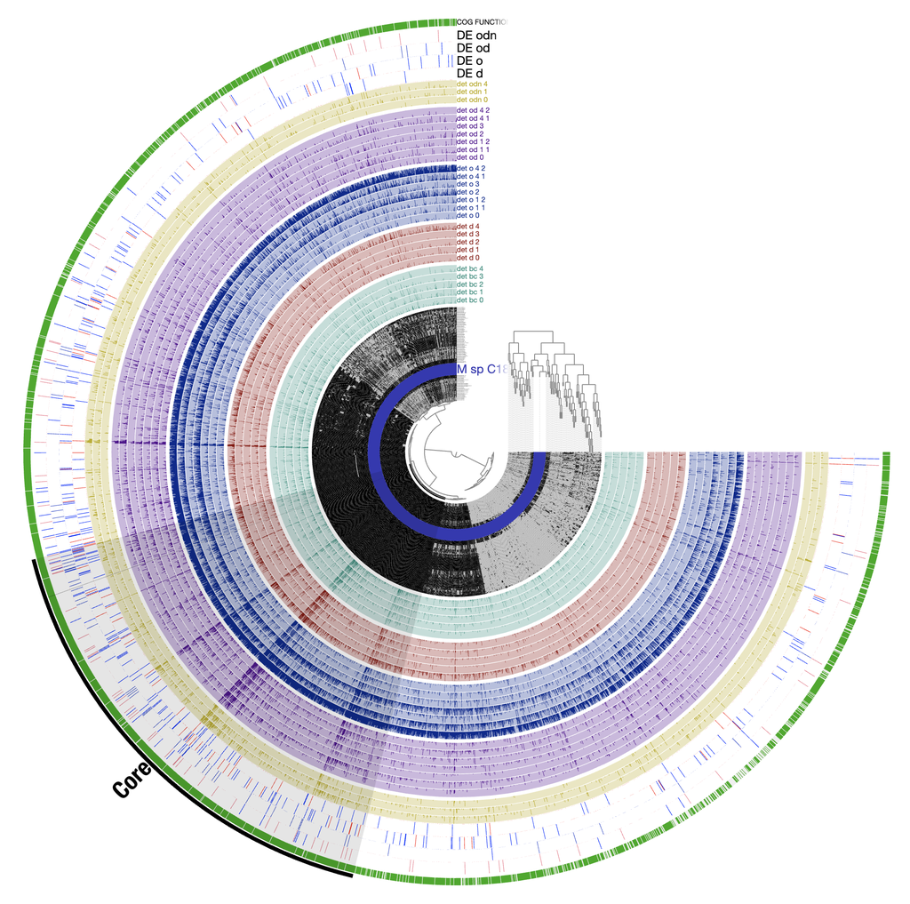

```python
Image(filename='Figure1.png')
```

### Barplot of up down DE genes

The following barplot will be added to the anvio plot. Anvio can add a layer to samples but not to the DE layer. So we do it here and later we add in inkscape.

```python
DE_for_anvio_df = pd.read_csv(r'/Users/tito_miniconda/JOYE_LAB_ANVIO_PROJECTS/SK_BACKUP/p28_pangenomes/Marinobacter/Marinobacter_DE_for_anvio.txt', sep = '\t')
col_vec = DE_for_anvio_df.columns
col_vec = col_vec[1:9]
d = col_vec.str.split('!').tolist()
barplot_data_df = pd.DataFrame(d)
barplot_data_df = barplot_data_df.rename(columns={0: "Treatment", 1: "DE_type"})
n = barplot_data_df.shape[0]
d = np.zeros(n)
barplot_data_df['DE_total'] = d.tolist()
for index,row in DE_for_anvio_df.iterrows():
    barplot_data_df['DE_total'] = row[1:9].tolist() + barplot_data_df.DE_total
```

```python
barplot_data_df
```

|  | Treatment | DE_type | DE_total |
| --- | --- | --- | --- |
| 0 | DE_d | A | 29.0 |
| 1 | DE_d | B | 76.0 |
| 2 | DE_o | A | 61.0 |
| 3 | DE_o | B | 179.0 |
| 4 | DE_od | A | 59.0 |
| 5 | DE_od | B | 40.0 |
| 6 | DE_odn | A | 89.0 |
| 7 | DE_odn | B | 37.0 |

```python
barplot_data_df = barplot_data_df.replace(to_replace=r'^A$', value='B_DownReg', regex=True)
barplot_data_df = barplot_data_df.replace(to_replace=r'^B$', value='A_UpReg', regex=True)
```

```python
barplot_4_anvio = alt.Chart(barplot_data_df).mark_bar().encode(
    x='Treatment',
    y='DE_total',
    color=alt.Color('DE_type', scale=alt.Scale(domain=['A_UpReg', 'B_DownReg'], range=['blue', 'red']))
).properties(
    width=100,
    height=100
)
```

```python
alt.renderers.enable('altair_saver')
barplot_4_anvio.save('barplot_4_anvio.svg', method = 'selenium')
```

### Layer of Interproscan annotation

```python
my_evalue = 1e-10
```

```python
#First we need to export the gene sequences present in
!anvi-get-sequences-for-gene-calls --get-aa-sequences -c 02_CONTIGS/Marinobacter_sp__C18_GCF_001924925_1-contigs.db -o ref_genome_genes.faa
```

```
Contigs DB ...................................: Initialized: 02_CONTIGS/Marinobacter_sp__C18_GCF_001924925_1-contigs.db (v. 14)

WARNING
===============================================
You did not provide any gene caller ids. As a result, anvi'o will give you back
sequences for every 4593 gene call stored in the contigs database.

                                                                                                                 [0m
WARNING
===============================================
Gene caller IDs 4591, 4592 have empty AA sequences and skipped.

Output .......................................: ref_genome_genes.faa
```

```python
#Now we need to select those genes that are in the SPLIT
pan_split_geneclusters_df = pan_split_geneclusters_df[pan_split_geneclusters_df.genome_name == 'M_sp__C18_GCF_001924925']
```

```python
list_genes_in_split = pan_split_geneclusters_df.gene_caller_id.unique().tolist()
```

```python
with open('list_genes_in_split.txt', 'w') as f:
    for item in list_genes_in_split:
        f.write("%s\n" % item)
```

```python
!cut -c 1- list_genes_in_split.txt | xargs -n 1 samtools faidx ref_genome_genes.faa > ref_genome_genes_in_split.faa
```

```python
#scp ref_genome_genes_in_split.faa  tdp56207@sapelo2.gacrc.uga.edu:/scratch/tdp56207/SK_BACKUP/p28_pangenome/Marinobacter/95_interproscan/
#module load Perl/5.20.3-foss-2016b
#perl ~/scripts/splitfasta.pl ref_genome_genes_in_split.faa splitseqs 50
#bring back results
#scp tdp56207@sapelo2.gacrc.uga.edu:/scratch/tdp56207/SK_BACKUP/p28_pangenome/Marinobacter/95_interproscan/results/tsv_files.tgz .
#mv tsv_files.tgz 95_interproscan/
#tar xzvf 95_interproscan/tsv_files.tgz
#cat tsv_files/splitseqs.*tsv > ref_genome_interproscan.tsv
```

```python
#load each output file and process it here
location = r'/Users/tito_miniconda/JOYE_LAB_ANVIO_PROJECTS/SK_BACKUP/p28_pangenomes/Marinobacter/95_interproscan/ref_genome_intersproscan.tsv'
my_int_df = pd.read_csv(location, sep='\t', header=None, names=['protein_id', 'md5', 'seq_len', 'source', 'accession', 'description', 'start', 'end', 'evalue', 'status', 'date', 'ipr_accession', 'ipr_description'])
```

```python
#Remove NA descriptions
mask1 = isNaN(my_int_df.description)
mask2 = isNaN(my_int_df.ipr_description)
mask3 = mask1 & mask2
mask4 = [not bool for bool in mask3]
my_int_df = my_int_df[mask4]
my_int_df = my_int_df[my_int_df.evalue != '-']
my_int_df['evalue'] = my_int_df['evalue'].astype(float)
my_int_df = my_int_df[my_int_df.evalue < my_evalue]
```

```python
genes_w_interproscan = my_int_df.protein_id.unique()
```

```python
location = r'/Users/tito_miniconda/JOYE_LAB_ANVIO_PROJECTS/SK_BACKUP/p28_pangenomes/Marinobacter/Marinobacter_DE_for_anvio.txt'
scheme_df = pd.read_csv(location, sep='\t')
scheme_df = scheme_df[['gene_cluster_id','DE_d!A']]
scheme_df.columns = ['gene_cluster_id','INTERPROSCAN']
scheme_df['INTERPROSCAN'] = scheme_df['INTERPROSCAN'].astype(str)
for index,row in scheme_df.iterrows():
    scheme_df.iloc[index,1]='UNKNOWN'
```

```python
for index,row in pan_split_geneclusters_df.iterrows():
    #if gene, which is row[1] is in the genes with annotation hit(s)
    if row[1] in genes_w_interproscan:
        my_index = scheme_df[scheme_df['gene_cluster_id'] == row[2]].index
        scheme_df.iloc[my_index[0],1] = 'KNOWN'
```

```python
scheme_df.to_csv(r'/Users/tito_miniconda/JOYE_LAB_ANVIO_PROJECTS/SK_BACKUP/p28_pangenomes/Marinobacter/Marinobacter_interpro_for_anvio.txt', index = False, sep='\t')
```

```python
!anvi-import-misc-data Marinobacter_interpro_for_anvio.txt -p SPLIT_PANs/T_signals/PAN.db --target-data-table items --just-do-it
```

```
New data for 'items' in data group 'default'
===============================================
Data key "INTERPROSCAN" ......................: Predicted type: str


NEW DATA
===============================================
Database .....................................: pan
Data group ...................................: default
Data table ...................................: items
New data keys ................................: INTERPROSCAN.
```

### Layer of text for later analysis

```python
DE_for_anvio_df = pd.read_csv(r'/Users/tito_miniconda/JOYE_LAB_ANVIO_PROJECTS/SK_BACKUP/p28_pangenomes/Marinobacter/Marinobacter_DE_for_anvio.txt', sep = '\t')
```

```python
#load each output file and process it here
location = r'/Users/tito_miniconda/JOYE_LAB_ANVIO_PROJECTS/SK_BACKUP/p28_pangenomes/Marinobacter/95_interproscan/ref_genome_intersproscan.tsv'
my_int_df = pd.read_csv(location, sep='\t', header=None, names=['protein_id', 'md5', 'seq_len', 'source', 'accession', 'description', 'start', 'end', 'evalue', 'status', 'date', 'ipr_accession', 'ipr_description'])
```

```python
#Remove NA descriptions
mask1 = isNaN(my_int_df.description)
mask2 = isNaN(my_int_df.ipr_description)
mask3 = mask1 & mask2
mask4 = [not bool for bool in mask3]
my_int_df = my_int_df[mask4]
my_int_df = my_int_df[my_int_df.evalue != '-']
my_int_df['evalue'] = my_int_df['evalue'].astype(float)
my_int_df = my_int_df[my_int_df.evalue < my_evalue]
```

```python
genes_w_interproscan = my_int_df.protein_id.unique()
```

```python
location = r'/Users/tito_miniconda/JOYE_LAB_ANVIO_PROJECTS/SK_BACKUP/p28_pangenomes/Marinobacter/Marinobacter_DE_for_anvio.txt'
scheme_df = pd.read_csv(location, sep='\t')
scheme_df = scheme_df[['gene_cluster_id','DE_d!A']]
scheme_df.columns = ['gene_cluster_id','INTERPROSCAN_TEXT']
scheme_df['INTERPROSCAN_TEXT'] = scheme_df['INTERPROSCAN_TEXT'].astype(str)
for index,row in scheme_df.iterrows():
    scheme_df.iloc[index,1]=''
```

```python
pan_split_geneclusters_df = pd.read_csv(r'/Users/tito_miniconda/JOYE_LAB_ANVIO_PROJECTS/SK_BACKUP/p28_pangenomes/Marinobacter/SPLIT_PANs/pan_split_gene_clusters.csv')
pan_split_geneclusters_df = pan_split_geneclusters_df[pan_split_geneclusters_df.genome_name == 'M_sp__C18_GCF_001924925']
```

```python
sum_col = DE_for_anvio_df['DE_d!A'] + DE_for_anvio_df['DE_d!B'] + DE_for_anvio_df['DE_o!A'] + DE_for_anvio_df['DE_o!B'] + DE_for_anvio_df['DE_od!A'] + DE_for_anvio_df['DE_od!B'] + DE_for_anvio_df['DE_odn!A'] + DE_for_anvio_df['DE_odn!B']
mask5 = sum_col != 0
gene_clusters_w_DE = DE_for_anvio_df[mask5].gene_cluster_id
```

```python
for index,row in pan_split_geneclusters_df.iterrows():
    if row[2] in gene_clusters_w_DE.tolist():
        temp = my_int_df[my_int_df.protein_id == row[1]]
        mask1_t = isNaN(temp.description)
        mask2_t = [not bool for bool in mask1_t]
        temp = temp[mask2_t]
        if not temp.empty:
            if isNaN(temp.iat[0,12]):
                my_test = str(temp.iat[0,0]) + '__' + temp.iat[0,5]
            else:
                my_test = str(temp.iat[0,0]) + '__' + temp.iat[0,12]
            my_index = scheme_df[scheme_df['gene_cluster_id'] == row[2]].index
            scheme_df.iloc[my_index[0],1] = my_test
```

```python
scheme_df.to_csv(r'/Users/tito_miniconda/JOYE_LAB_ANVIO_PROJECTS/SK_BACKUP/p28_pangenomes/Marinobacter/Marinobacter_interpro_labels_for_anvio.txt', index = False, sep='\t')
```

```python
!anvi-import-misc-data Marinobacter_interpro_labels_for_anvio.txt -p SPLIT_PANs/T_signals/PAN.db --target-data-table items --just-do-it
```

```
New data for 'items' in data group 'default'
===============================================
Data key "INTERPROSCAN_TEXT" .................: Predicted type: str


WARNING
===============================================
The following keys in your data dict will replace the ones that are already in
your pan database items table and default data group: INTERPROSCAN_TEXT.


WARNING
===============================================
Data from the table 'items' for the following data keys in data group 'default'
removed from the database: 'INTERPROSCAN_TEXT'. #SAD.


NEW DATA
===============================================
Database .....................................: pan
Data group ...................................: default
Data table ...................................: items
New data keys ................................: INTERPROSCAN_TEXT.
```

The last thing I would like to add to this diagram is

1- Numbers around the circle pointing to critical genes to discuss in the paper.

2- Empty space would be used to show the an expanded tree

To visualize

```
anvi-display-pan -p SPLIT_PANs/T_signals/PAN.db -g MARINOBACTER_GENOMES.db
```

```python
#The following file may be usefull while working in the last version of the figure.
!anvi-export-functions -c 02_CONTIGS/Marinobacter_sp__C18_GCF_001924925_1-contigs.db -o ref_genome_cogs.txt
```

```
Annotation sources ...........................: COG_CATEGORY, COG_FUNCTION.                       [0m
Number of annotations reported ...............: 7,318                                             [0m
Output file ..................................: ref_genome_cogs.txt
```

## Selecting and splitting only GC containing DE genes.

Anvio diagram is getting too difficult to label names. So we are going to select and split bins that only contain DE genes. Selection was done using the search box and now we proceed to split again.

```python
!anvi-split -p SPLIT_PANs/T_signals/PAN.db -g MARINOBACTER_GENOMES.db -C DE_Genes -o SPLIT_DE_Genes
```

```
Genomes storage .............................................: Initialized (storage hash: hashcbee1777)8;5;0m ETA: 0s
Num genomes in storage ......................................: 113
Num genomes will be used ....................................: 113
Pan DB ......................................................: Initialized: SPLIT_PANs/T_signals/PAN.db (v. 13)
Gene cluster homogeneity estimates ..........................: Functional: [YES]; Geometric: [YES]; Combined: [YES]
                                                                                                                        [0m
* Gene clusters are initialized for all 3924 gene clusters in the database.

                                                                                                                 [0m
WARNING
==============================================================
Anvi'o is about to start splitting your bins into individual, self-contained
anvi'o profiles. This is quite a tricky operation, and even if it finishes
successfully, you must double check everyting in the resulting profiles to make
sure things worked as expected. Although we are doing our best to test all
these, variation between projects make it impossible to be 100% sure.

Collections ..................................: The collection "DEFAULT" that describes 342 splits and 1 bins has been successfully added to the database at "SPLIT_DE_Genes/DE_Genes/PAN.db". Here is a full list of the bin names in this collection: ALL_SPLITS.
New items order ..............................: "frequency:euclidean:ward" (type newick) has been added to the database...
                                                                                                                 [0m
WARNING
===============================================
Clustering for "frequency:euclidean:ward" is already in the database. It will be
replaced with the new content.

New items order ..............................: "frequency:euclidean:ward" (type newick) has been added to the database...
New items order ..............................: "presence-absence:euclidean:ward" (type newick) has been added to the database...
Num bins processed ..........................................: 1
Output directory ............................................: /Users/tito_miniconda/JOYE_LAB_ANVIO_PROJECTS/SK_BACKUP/p28_pangenomes/Marinobacter/SPLIT_DE_Genes
```

`anvi-display-pan -p SPLIT_DE_Genes/DE_genes/PAN.db -g MARINOBACTER_GENOMES.db`

## KEGG Annotation of DE Genes

`anvi-get-sequences-for-gene-clusters -p SPLIT_DE_Genes/DE_Genes/PAN.db -g MARINOBACTER_GENOMES.db -o DE_Genes_Split_AA.fa`

Then we filter only for M. sp. C18

`cat DE_Genes_Split_AA.fa | tr '\n' '%' | sed -e 's/%>/\'$'\n>/g' | grep --color 'C18' | sed -e 's/%/\'$'\n/g' > DE_Genes_Split_AA_C18.fa`

KEGG annotation was run in

https://www.genome.jp/kaas-bin/kaas_main

choosing GHOSTZ and Representative for Procaryotes options.

## Static HTML output

Now our metapangenome is ready to generate an static HTML output.

`anvi-summarize -p SPLIT_DE_Genes/DE_genes/PAN.db -g MARINOBACTER_GENOMES.db -o SPLIT_DE_Genes-SUMMARY -C core_v2`

## Supplemetary Data 2

```python
sup_data_df_p1 = pd.read_csv(r'/Users/tito_miniconda/JOYE_LAB_ANVIO_PROJECTS/SK_BACKUP/p28_pangenomes/Marinobacter/Marinobacter_DE_w_description.txt', sep = '\t')
```

```python
sup_data_df_p1
```

|  | entry_id | gene_caller_id | gene_cluster_id | genome_name | alignment_summary | baseMean | log2FoldChange | lfcSE | stat | pvalue | padj | zeros_in_bc | treatment | bc_mean | treat_mean | t_test_p_value |
| --- | --- | --- | --- | --- | --- | --- | --- | --- | --- | --- | --- | --- | --- | --- | --- | --- |
| 0 | 156 | 2789 | GC_00000001 | M_sp__C18_GCF_001924925 | -\|140\|26\|1\|11\|1\|31\|3 | 6562.331151 | -0.032557 | 0.105387 | 0.090255 | 7.638527e-01 | 1.000000e+00 | 0 | d | 4347.6 | 9219.400000 | 0.009507 |
| 1 | 156 | 2789 | GC_00000001 | M_sp__C18_GCF_001924925 | -\|140\|26\|1\|11\|1\|31\|3 | 4104.266641 | 0.470153 | 0.129866 | 299.508995 | 4.214490e-67 | 2.068846e-65 | 0 | od | 4347.6 | 3322.857143 | 0.587184 |
| 2 | 457 | 544 | GC_00000001 | M_sp__C18_GCF_001924925 | -\|6\|84\|2\|20\|8\|14\|1\|31\|1\|11\|1\|33\|1 | 84.034766 | -0.007767 | 0.182366 | 0.000949 | 9.754292e-01 | 1.000000e+00 | 5 | o | 0.0 | 150.000000 | 0.034792 |
| 3 | 497 | 2331 | GC_00000002 | M_sp__C18_GCF_001924925 | -\|65\|34\|65\|23\|65\|328\|8\|13\|90 | 778.767260 | -0.031415 | 0.092460 | 0.110771 | 7.392677e-01 | 1.000000e+00 | 0 | odn | 539.0 | 1079.333333 | 0.007956 |
| 4 | 909 | 4198 | GC_00000003 | M_sp__C18_GCF_001924925 | -\|2\|11\|7\|132\|2\|2\|2\|323\|6 | 45.027417 | 0.123710 | 0.201310 | -20.830590 | 1.000000e+00 | 1.000000e+00 | 5 | o | 0.0 | 65.714286 | 0.048678 |
| ... | ... | ... | ... | ... | ... | ... | ... | ... | ... | ... | ... | ... | ... | ... | ... | ... |
| 565 | 417097 | 3173 | GC_00014438 | M_sp__C18_GCF_001924925 | .\|130\|38\|124 | 1041.550391 | -0.122083 | 0.202282 | 113.169938 | 1.980517e-26 | 2.726405e-25 | 2 | odn | 1502.6 | 586.333333 | 0.392385 |
| 566 | 421022 | 2516 | GC_00016207 | M_sp__C18_GCF_001924925 | .\|235 | 86.008099 | 0.105524 | 0.200852 | -33.988787 | 1.000000e+00 | 1.000000e+00 | 5 | o | 0.0 | 145.571429 | 0.040483 |
| 567 | 424030 | 1667 | GC_00017711 | M_sp__C18_GCF_001924925 | .\|291\|3 | 216.185158 | -0.025383 | 0.141729 | 0.017593 | 8.944787e-01 | 1.000000e+00 | 5 | o | 0.0 | 312.571429 | 0.001928 |
| 568 | 425329 | 2700 | GC_00018360 | M_sp__C18_GCF_001924925 | .\|769 | 142.694554 | 0.111093 | 0.200773 | -40.974886 | 1.000000e+00 | 1.000000e+00 | 5 | o | 0.0 | 215.285714 | 0.034119 |
| 569 | 441939 | 384 | GC_00032784 | M_sp__C18_GCF_001924925 | NaN | 3384.244789 | 0.091946 | 0.193332 | -3.063565 | 1.000000e+00 | 1.000000e+00 | 3 | o | 607.6 | 4351.285714 | 0.038144 |

570 rows × 16 columns

```python
sup_data_df_p2 = pd.read_csv(r'/Users/tito_miniconda/JOYE_LAB_ANVIO_PROJECTS/SK_BACKUP/p28_pangenomes/Marinobacter/97_FIGURES/NameReferences_v2.txt', sep = '\t')
```

```python
sup_data_df = pd.merge(sup_data_df_p1, sup_data_df_p2, on='gene_caller_id')
```

```python
sup_data_df
```

|  | entry_id | gene_caller_id | gene_cluster_id | genome_name | alignment_summary | baseMean | log2FoldChange | lfcSE | stat | pvalue | ... | treatment | bc_mean | treat_mean | t_test_p_value | KEGG | gene_cluster | anvio_order | protein_family | COG_cat | COG_desc |
| --- | --- | --- | --- | --- | --- | --- | --- | --- | --- | --- | --- | --- | --- | --- | --- | --- | --- | --- | --- | --- | --- |
| 0 | 156 | 2789 | GC_00000001 | M_sp__C18_GCF_001924925 | -\|140\|26\|1\|11\|1\|31\|3 | 6562.331151 | -0.032557 | 0.105387 | 0.090255 | 7.638527e-01 | ... | d | 4347.6 | 9219.400000 | 0.009507 | K03704 | GC_00000001 | 181.0 | CspA | NaN | NaN |
| 1 | 156 | 2789 | GC_00000001 | M_sp__C18_GCF_001924925 | -\|140\|26\|1\|11\|1\|31\|3 | 4104.266641 | 0.470153 | 0.129866 | 299.508995 | 4.214490e-67 | ... | od | 4347.6 | 3322.857143 | 0.587184 | K03704 | GC_00000001 | 181.0 | CspA | NaN | NaN |
| 2 | 457 | 544 | GC_00000001 | M_sp__C18_GCF_001924925 | -\|6\|84\|2\|20\|8\|14\|1\|31\|1\|11\|1\|33\|1 | 84.034766 | -0.007767 | 0.182366 | 0.000949 | 9.754292e-01 | ... | o | 0.0 | 150.000000 | 0.034792 | K03704 | GC_00000001 | 181.0 | CspA | K | NaN |
| 3 | 497 | 2331 | GC_00000002 | M_sp__C18_GCF_001924925 | -\|65\|34\|65\|23\|65\|328\|8\|13\|90 | 778.767260 | -0.031415 | 0.092460 | 0.110771 | 7.392677e-01 | ... | odn | 539.0 | 1079.333333 | 0.007956 | K02358 | GC_00000002 | 180.0 | NaN | NaN | NaN |
| 4 | 909 | 4198 | GC_00000003 | M_sp__C18_GCF_001924925 | -\|2\|11\|7\|132\|2\|2\|2\|323\|6 | 45.027417 | 0.123710 | 0.201310 | -20.830590 | 1.000000e+00 | ... | o | 0.0 | 65.714286 | 0.048678 | K03308 | GC_00000003 | 179.0 | YocR | NaN | NaN |
| ... | ... | ... | ... | ... | ... | ... | ... | ... | ... | ... | ... | ... | ... | ... | ... | ... | ... | ... | ... | ... | ... |
| 492 | 408091 | 2512 | GC_00011507 | M_sp__C18_GCF_001924925 | .\|89\|248\|5\|1\|12\|4\|7\|4\|41\|206 | 144.049889 | 0.199251 | 0.200330 | 0.333062 | 5.638614e-01 | ... | o | 0.0 | 233.714286 | 0.034751 | NaN | GC_00011507 | 312.0 | NaN | L | NaN |
| 493 | 417097 | 3173 | GC_00014438 | M_sp__C18_GCF_001924925 | .\|130\|38\|124 | 1746.346354 | 0.076501 | 0.191963 | 44.365982 | 2.723793e-11 | ... | o | 1502.6 | 1743.142857 | 0.823288 | NaN | GC_00014438 | 314.0 | UbiE | H | COG2226 |
| 494 | 417097 | 3173 | GC_00014438 | M_sp__C18_GCF_001924925 | .\|130\|38\|124 | 1041.550391 | -0.122083 | 0.202282 | 113.169938 | 1.980517e-26 | ... | odn | 1502.6 | 586.333333 | 0.392385 | NaN | GC_00014438 | 314.0 | UbiE | H | COG2226 |
| 495 | 424030 | 1667 | GC_00017711 | M_sp__C18_GCF_001924925 | .\|291\|3 | 216.185158 | -0.025383 | 0.141729 | 0.017593 | 8.944787e-01 | ... | o | 0.0 | 312.571429 | 0.001928 | NaN | GC_00017711 | 315.0 | NaN | K | NaN |
| 496 | 441939 | 384 | GC_00032784 | M_sp__C18_GCF_001924925 | NaN | 3384.244789 | 0.091946 | 0.193332 | -3.063565 | 1.000000e+00 | ... | o | 607.6 | 4351.285714 | 0.038144 | NaN | GC_00032784 | 313.0 | NaN | S | NaN |

497 rows × 22 columns

```python
sup_data_df.to_csv(r'/Users/tito_miniconda/JOYE_LAB_ANVIO_PROJECTS/SK_BACKUP/p28_pangenomes/Marinobacter/97_FIGURES/Marinobacter_supplementary_data_2.txt', index = False, sep='\t')
```